# MonarchR Basics

Shawn T O’Neil

Vignette updated: *Feb-13-2026

# Background: Biomedical Knowledge Graphs

Knowledge graphs (KGs) represent entities (such as genes, diseases, or phenotypes) and the relationships between them; for example that the `CFTR` gene `causes` the disease `Cystic fibrosis`. In the [Monarch Initiative](https://monarchiniative.org) KG, this information is stored in a *directed, labeled property graph*, with properties attached to the entities (nodes) and relationships (edges). The [KGX format](https://github.com/biolink/kgx/blob/master/specification/kgx-format.md) used by Monarch provides a simple specification for KGs:

- Nodes must have an `id` property
- Nodes must have a `category` property, as a multi-valued set of category labels
- Edges must have `subject`, `predicate`, and `object` properties, representing the source, relationship, and destination of the edge.
- Nodes and edges may have additional properties, and these may be multi-valued.

In the following figure, these required properties are shown in bold:

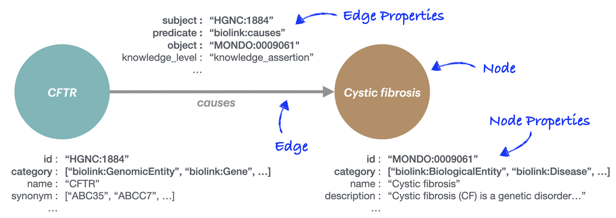

Small KG visualization showing node and edge properties, with id, category, subject, and object bolded, and other properties such as name present.

The `monarchr` package provides access to the cloud-hosted Monarch Initiative KG, and [others in KGX format](https://kghub.org) via graph-database and file-based “engines”, with a simple but flexible set of query functions. The example below finds all of the sub-types of [Neimann-Pick Disease](https://monarchinitiative.org/MONDO:0001982), and all of the genes associated with those. (You an use the [Monarch Initiative](https://monarchiniative.org) website to identify IDs for genes, diseases, phenotypes and more, or `search_nodes()` described below.)

```r
# MONDO:0001982 Niemann-Pick Disease (13 subtypes)

g <- monarch_engine() |>
    fetch_nodes(query_ids = c("MONDO:0001982")) |>
    expand(predicates = "biolink:subclass_of", direction = "in", transitive = TRUE) |>
    expand(categories = "biolink:Gene")
```

```
## Trying to connect to https://neo4j.monarchinitiative.org
```

```
## Connected to https://neo4j.monarchinitiative.org
```

```
## Fetching; counting matching nodes...  total: 1.
## Fetching; fetched 1 of 1
## Expanding; counting matching edges...  total: 13.
## Expanding; fetched 13 of 13 edges.
## Expanding; counting matching edges...  total: 17.
## Expanding; fetched 17 of 17 edges.
```

```
## Using "sugiyama" as default layout
```

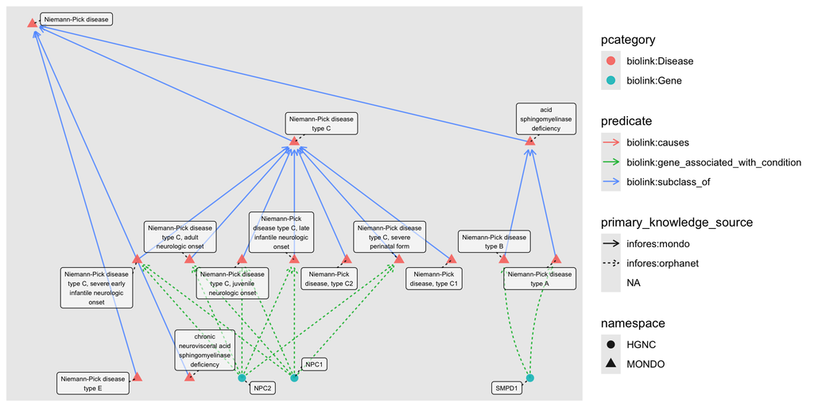

```r
plot(g)
```

```r
g
```

```
Graph with 17 nodes and 30 edges. Expand sections below for details.
```

**Node Data**

Showing 17 of 17 nodes:

| id | pcategory | name | symbol | in_taxon_label | description | synonym (list) | category (list) | iri | xref (list) | file_source | narrow_synonym (list) | namespace | provided_by | exact_synonym (list) | subsets | broad_synonym (list) | related_synonym (list) | in_taxon | type | full_name |
| --- | --- | --- | --- | --- | --- | --- | --- | --- | --- | --- | --- | --- | --- | --- | --- | --- | --- | --- | --- | --- |
| “MONDO:0001982” | “biolink:Disease” | “Niemann-Pick disease” | NA | NA | “A group of inherited, severe metabolic disorders in which sphingomyelin accumulates in lysosomes in cells. The lysosomes normally transport material through and out of the cell.” | c(“Niemann-Pick disease with cholesterol esterification block”, “Niemann-Pick disease, subacute juvenile form”, “lipoid histiocytosis”, “lipoid histiocytosis (classical phosphatide)”, “sphingomyelin l… | c(“biolink:Disease”, “biolink:DiseaseOrPhenotypicFeature”, “biolink:OntologyClass”, “biolink:BiologicalEntity”, “biolink:ThingWithTaxon”, “biolink:NamedThing”, “biolink:Entity”) | “http://purl.obolibrary.org/obo/MONDO_0001982” | c(“DOID:14504”, “EFO:1001380”, “GARD:13334”, “ICD10CM:E75.24”, “MEDGEN:10348”, “MESH:D009542”, “NANDO:2200561”, “NCIT:C61269”, “SCTID:58459009”, “UMLS:C0028064”, “icd11.foundation:398872780”) | “phenio_nodes” | “type A Niemann-Pick disease” | “MONDO” | “phenio_nodes” | c(“Niemann-Pick disease with cholesterol esterification block”, “Niemann-Pick disease, subacute juvenile form”, “lipoid histiocytosis”, “lipoid histiocytosis (classical phosphatide)”, “sphingomyelin l… | “gard_rare\|nord_rare\|otar\|rare” | NA | NA | NA | NA | NA |
| “MONDO:0018982” | “biolink:Disease” | “Niemann-Pick disease type C” | NA | NA | “NPC is a complex lipid storage disease mainly characterized by the accumulation of unesterified cholesterol in the late endosomal/lysosomal compartment.” | c(“NPC”, “Niemann Pick Disease Type C”) | c(“biolink:Disease”, “biolink:DiseaseOrPhenotypicFeature”, “biolink:OntologyClass”, “biolink:BiologicalEntity”, “biolink:ThingWithTaxon”, “biolink:NamedThing”, “biolink:Entity”) | “http://purl.obolibrary.org/obo/MONDO_0018982” | c(“GARD:7207”, “ICD10CM:E75.242”, “MEDGEN:67399”, “MESH:D052556”, “NANDO:1200063”, “NORD:1509”, “Orphanet:646”, “SCTID:66751000”, “UMLS:C0220756”, “icd11.foundation:812702125”) | “phenio_nodes” | NA | “MONDO” | “phenio_nodes” | “Niemann Pick Disease Type C” | “gard_rare\|nord_rare\|ordo_disorder\|orphanet_rare\|otar\|rare” | “NPC” | NA | NA | NA | NA |
| “MONDO:0016306” | “biolink:Disease” | “Niemann-Pick disease type C, severe perinatal form” | NA | NA | NA | NA | c(“biolink:Disease”, “biolink:DiseaseOrPhenotypicFeature”, “biolink:OntologyClass”, “biolink:BiologicalEntity”, “biolink:ThingWithTaxon”, “biolink:NamedThing”, “biolink:Entity”) | “http://purl.obolibrary.org/obo/MONDO_0016306” | c(“GARD:20504”, “MEDGEN:1842349”, “Orphanet:216972”, “UMLS:C5680866”) | “phenio_nodes” | NA | “MONDO” | “phenio_nodes” | NA | “gard_rare\|nord_rare\|ordo_subtype_of_a_disorder\|otar\|rare” | NA | NA | NA | NA | NA |
| “MONDO:0016307” | “biolink:Disease” | “Niemann-Pick disease type C, severe early infantile neurologic onset” | NA | NA | NA | NA | c(“biolink:Disease”, “biolink:DiseaseOrPhenotypicFeature”, “biolink:OntologyClass”, “biolink:BiologicalEntity”, “biolink:ThingWithTaxon”, “biolink:NamedThing”, “biolink:Entity”) | “http://purl.obolibrary.org/obo/MONDO_0016307” | c(“GARD:20505”, “MEDGEN:1842400”, “Orphanet:216975”, “UMLS:C5680868”, “icd11.foundation:587642791”) | “phenio_nodes” | NA | “MONDO” | “phenio_nodes” | NA | “gard_rare\|nord_rare\|ordo_subtype_of_a_disorder\|otar\|rare” | NA | NA | NA | NA | NA |
| “MONDO:0016308” | “biolink:Disease” | “Niemann-Pick disease type C, late infantile neurologic onset” | NA | NA | NA | NA | c(“biolink:Disease”, “biolink:DiseaseOrPhenotypicFeature”, “biolink:OntologyClass”, “biolink:BiologicalEntity”, “biolink:ThingWithTaxon”, “biolink:NamedThing”, “biolink:Entity”) | “http://purl.obolibrary.org/obo/MONDO_0016308” | c(“GARD:20506”, “MEDGEN:1843353”, “Orphanet:216978”, “UMLS:C5680867”, “icd11.foundation:2075382821”) | “phenio_nodes” | NA | “MONDO” | “phenio_nodes” | NA | “gard_rare\|nord_rare\|ordo_subtype_of_a_disorder\|otar\|rare” | NA | NA | NA | NA | NA |
| “MONDO:0016309” | “biolink:Disease” | “Niemann-Pick disease type C, juvenile neurologic onset” | NA | NA | NA | “Niemann-Pick disease type C, classic form” | c(“biolink:Disease”, “biolink:DiseaseOrPhenotypicFeature”, “biolink:OntologyClass”, “biolink:BiologicalEntity”, “biolink:ThingWithTaxon”, “biolink:NamedThing”, “biolink:Entity”) | “http://purl.obolibrary.org/obo/MONDO_0016309” | c(“GARD:20507”, “MEDGEN:1842257”, “Orphanet:216981”, “UMLS:C5679813”, “icd11.foundation:2006062681”) | “phenio_nodes” | NA | “MONDO” | “phenio_nodes” | “Niemann-Pick disease type C, classic form” | “gard_rare\|nord_rare\|ordo_subtype_of_a_disorder\|otar\|rare” | NA | NA | NA | NA | NA |
| “MONDO:0016310” | “biolink:Disease” | “Niemann-Pick disease type C, adult neurologic onset” | NA | NA | NA | NA | c(“biolink:Disease”, “biolink:DiseaseOrPhenotypicFeature”, “biolink:OntologyClass”, “biolink:BiologicalEntity”, “biolink:ThingWithTaxon”, “biolink:NamedThing”, “biolink:Entity”) | “http://purl.obolibrary.org/obo/MONDO_0016310” | c(“GARD:20508”, “MEDGEN:1826101”, “NANDO:1200065”, “NANDO:2201209”, “Orphanet:216986”, “UMLS:C5680869”, “icd11.foundation:77127214”) | “phenio_nodes” | NA | “MONDO” | “phenio_nodes” | NA | “gard_rare\|nord_rare\|ordo_subtype_of_a_disorder\|otar\|rare” | NA | NA | NA | NA | NA |
| “MONDO:0020384” | “biolink:Disease” | “Niemann-Pick disease type E” | NA | NA | “Niemann-Pick disease, type E is a poorly defined adult-onset and non-neuronopathic form of Niemann-Pick disease.” | NA | c(“biolink:Disease”, “biolink:DiseaseOrPhenotypicFeature”, “biolink:OntologyClass”, “biolink:BiologicalEntity”, “biolink:ThingWithTaxon”, “biolink:NamedThing”, “biolink:Entity”) | “http://purl.obolibrary.org/obo/MONDO_0020384” | c(“MEDGEN:82781”, “Orphanet:99022”, “SCTID:73399005”, “UMLS:C0268248”) | “phenio_nodes” | NA | “MONDO” | “phenio_nodes” | NA | “gard_rare\|otar\|rare” | NA | NA | NA | NA | NA |
| “MONDO:0100464” | “biolink:Disease” | “acid sphingomyelinase deficiency” | NA | NA | “An autosomal recessive lysosomal disease caused by biallelic loss of function variants in the SMPD1 gene. Clinical symptoms in affected individuals occur along a continuum. At the severe end of the s… | NA | c(“biolink:Disease”, “biolink:DiseaseOrPhenotypicFeature”, “biolink:OntologyClass”, “biolink:BiologicalEntity”, “biolink:ThingWithTaxon”, “biolink:NamedThing”, “biolink:Entity”) | “http://purl.obolibrary.org/obo/MONDO_0100464” | c(“MEDGEN:1800807”, “UMLS:C5243927”) | “phenio_nodes” | NA | “MONDO” | “phenio_nodes” | NA | “clingen\|gard_rare\|otar\|rare” | NA | NA | NA | NA | NA |
| “MONDO:0850058” | “biolink:Disease” | “chronic neurovisceral acid sphingomyelinase deficiency” | NA | NA | NA | NA | c(“biolink:Disease”, “biolink:DiseaseOrPhenotypicFeature”, “biolink:OntologyClass”, “biolink:BiologicalEntity”, “biolink:ThingWithTaxon”, “biolink:NamedThing”, “biolink:Entity”) | “http://purl.obolibrary.org/obo/MONDO_0850058” | c(“GARD:22456”, “ICD10CM:E75.244”, “MEDGEN:1842316”, “Orphanet:618891”, “UMLS:C5539139”) | “phenio_nodes” | NA | “MONDO” | “phenio_nodes” | NA | “gard_rare\|nord_rare\|ordo_disorder\|orphanet_rare\|rare” | NA | NA | NA | NA | NA |
| “MONDO:0009756” | “biolink:Disease” | “Niemann-Pick disease type A” | NA | NA | “Niemann-Pick disease type A is a very severe subtype of Niemann-Pick disease, an autosomal recessive lysosomal disease, and is characterized clinically by onset in infancy or early childhood with fai… | c(“Niemann-PICK disease, type A”, “Niemann-Pick disease, Intermediate, protracted neurovisceral”, “sphingomyelin lipidosis”, “sphingomyelinase deficiency”) | c(“biolink:Disease”, “biolink:DiseaseOrPhenotypicFeature”, “biolink:OntologyClass”, “biolink:BiologicalEntity”, “biolink:ThingWithTaxon”, “biolink:NamedThing”, “biolink:Entity”) | “http://purl.obolibrary.org/obo/MONDO_0009756” | c(“DOID:0070111”, “GARD:7206”, “ICD10CM:E75.240”, “MEDGEN:78650”, “MESH:D052536”, “NANDO:1200061”, “NANDO:2201206”, “NCIT:C126561”, “OMIM:257200”, “Orphanet:77292”, “SCTID:52165006”, “UMLS:C0268242”, … | “phenio_nodes” | NA | “MONDO” | “phenio_nodes” | NA | “gard_rare\|nord_rare\|ordo_disorder\|orphanet_rare\|otar\|rare” | NA | c(“Niemann-PICK disease, type A”, “Niemann-Pick disease, Intermediate, protracted neurovisceral”, “sphingomyelin lipidosis”, “sphingomyelinase deficiency”) | NA | NA | NA |
| “MONDO:0009757” | “biolink:Disease” | “Niemann-Pick disease, type C1” | NA | NA | “Type C Niemann-Pick disease associated with a mutation in the gene NPC1, encoding Niemann-Pick C1 protein.” | c(“NPC1”, “Niemann-PICK disease, type C1”, “Niemann-Pick disease type C1”, “Niemann-Pick disease with cholesterol esterification block”, “Niemann-Pick disease without sphingomyelinase deficiency”, “Ni… | c(“biolink:Disease”, “biolink:DiseaseOrPhenotypicFeature”, “biolink:OntologyClass”, “biolink:BiologicalEntity”, “biolink:ThingWithTaxon”, “biolink:NamedThing”, “biolink:Entity”) | “http://purl.obolibrary.org/obo/MONDO_0009757” | c(“DOID:0070113”, “MEDGEN:465922”, “NCIT:C126864”, “OMIM:257220”, “SCTID:18927009”, “SCTID:67855008”, “UMLS:C3179455”) | “phenio_nodes” | NA | “MONDO” | “phenio_nodes” | c(“Niemann-Pick disease, type C1”, “type C1 Niemann-Pick disease”) | “clingen\|gard_rare\|rare” | NA | c(“NPC1”, “Niemann-PICK disease, type C1”, “Niemann-Pick disease type C1”, “Niemann-Pick disease with cholesterol esterification block”, “Niemann-Pick disease without sphingomyelinase deficiency”, “Ni… | NA | NA | NA |
| “MONDO:0011871” | “biolink:Disease” | “Niemann-Pick disease type B” | NA | NA | “Niemann-Pick disease type B is a mild subtype of Niemann-Pick disease, an autosomal recessive lysosomal disease, and is characterized clinically by onset in childhood with hepatosplenomegaly, growth … | c(“Niemann Pick disease type B”, “Niemann-PICK disease, type B”, “Niemann-Pick disease, Intermediate, with visceral involvement and rapid progression”, “Niemann-Pick disease, type E”, “Niemann-Pick di… | c(“biolink:Disease”, “biolink:DiseaseOrPhenotypicFeature”, “biolink:OntologyClass”, “biolink:BiologicalEntity”, “biolink:ThingWithTaxon”, “biolink:NamedThing”, “biolink:Entity”) | “http://purl.obolibrary.org/obo/MONDO_0011871” | c(“DOID:0070112”, “GARD:10729”, “ICD10CM:E75.241”, “MEDGEN:78651”, “MESH:D052537”, “NANDO:1200062”, “NANDO:2201207”, “NCIT:C126866”, “OMIM:607616”, “Orphanet:77293”, “SCTID:39390005”, “UMLS:C0268243”,… | “phenio_nodes” | NA | “MONDO” | “phenio_nodes” | “type B Niemann-Pick disease” | “gard_rare\|nord_rare\|ordo_disorder\|orphanet_rare\|otar\|rare” | NA | c(“Niemann Pick disease type B”, “Niemann-PICK disease, type B”, “Niemann-Pick disease, Intermediate, with visceral involvement and rapid progression”, “Niemann-Pick disease, type E”, “Niemann-Pick di… | NA | NA | NA |
| “MONDO:0011873” | “biolink:Disease” | “Niemann-Pick disease, type C2” | NA | NA | “Niemann-Pick disease type C2 is a rare metabolic condition that affects many different parts of the body. Although signs and symptoms can develop at any age (infancy through adulthood), most affected… | c(“NPC2”, “Niemann-PICK disease, type C2”, “Niemann-Pick disease type C2”, “Niemann-Pick disease, type C2”, “type C2 Niemann-Pick disease”) | c(“biolink:Disease”, “biolink:DiseaseOrPhenotypicFeature”, “biolink:OntologyClass”, “biolink:BiologicalEntity”, “biolink:ThingWithTaxon”, “biolink:NamedThing”, “biolink:Entity”) | “http://purl.obolibrary.org/obo/MONDO_0011873” | c(“DOID:0070114”, “GARD:3992”, “MEDGEN:335942”, “MESH:C536119”, “NCIT:C126865”, “OMIM:607625”, “UMLS:C1843366”) | “phenio_nodes” | NA | “MONDO” | “phenio_nodes” | c(“NPC2”, “Niemann-Pick disease, type C2”, “type C2 Niemann-Pick disease”) | “clingen\|gard_rare\|rare” | NA | c(“Niemann-PICK disease, type C2”, “Niemann-Pick disease type C2”) | NA | NA | NA |
| “HGNC:14537” | “biolink:Gene” | “NPC2” | “NPC2” | “Homo sapiens” | NA | c(“HE1”, “NP-C2”, “EDDM1”, “epididymal protein 1”, “Niemann-Pick disease, type C2”) | c(“biolink:Gene”, “biolink:GeneOrGeneProduct”, “biolink:GenomicEntity”, “biolink:ChemicalEntityOrGeneOrGeneProduct”, “biolink:PhysicalEssence”, “biolink:OntologyClass”, “biolink:BiologicalEntity”, “bi… | NA | c(“ENSEMBL:ENSG00000119655”, “OMIM:601015”) | “hgnc_gene_nodes” | NA | “HGNC” | “hgnc_gene_nodes” | NA | NA | NA | NA | “NCBITaxon:9606” | “SO:0001217” | “NPC intracellular cholesterol transporter 2” |
| “HGNC:7897” | “biolink:Gene” | “NPC1” | “NPC1” | “Homo sapiens” | NA | c(“SLC65A1”, “Niemann-Pick disease, type C1”) | c(“biolink:Gene”, “biolink:GeneOrGeneProduct”, “biolink:GenomicEntity”, “biolink:ChemicalEntityOrGeneOrGeneProduct”, “biolink:PhysicalEssence”, “biolink:OntologyClass”, “biolink:BiologicalEntity”, “bi… | NA | c(“ENSEMBL:ENSG00000141458”, “OMIM:607623”) | “hgnc_gene_nodes” | NA | “HGNC” | “hgnc_gene_nodes” | NA | NA | NA | NA | “NCBITaxon:9606” | “SO:0001217” | “NPC intracellular cholesterol transporter 1” |
| “HGNC:11120” | “biolink:Gene” | “SMPD1” | “SMPD1” | “Homo sapiens” | NA | c(“ASM”, “acid sphingomyelinase”, “Niemann-Pick type A/B”, “sphingomyelin phosphodiesterase 1, acid lysosomal”) | c(“biolink:Gene”, “biolink:GeneOrGeneProduct”, “biolink:GenomicEntity”, “biolink:ChemicalEntityOrGeneOrGeneProduct”, “biolink:PhysicalEssence”, “biolink:OntologyClass”, “biolink:BiologicalEntity”, “bi… | NA | c(“ENSEMBL:ENSG00000166311”, “OMIM:607608”) | “hgnc_gene_nodes” | NA | “HGNC” | “hgnc_gene_nodes” | NA | NA | NA | NA | “NCBITaxon:9606” | “SO:0001217” | “sphingomyelin phosphodiesterase 1” |

**Edge Data**

Showing 30 of 30 edges:

| from | to | subject | predicate | object | primary_knowledge_source | agent_type | knowledge_level | aggregator_knowledge_source (list) | provided_by | file_source | id | category (list) | original_subject | original_object |
| --- | --- | --- | --- | --- | --- | --- | --- | --- | --- | --- | --- | --- | --- | --- |
| 3 | 2 | “MONDO:0016306” | “biolink:subclass_of” | “MONDO:0018982” | “infores:mondo” | “not_provided” | “not_provided” | c(“infores:monarchinitiative”, “infores:phenio”) | “phenio_edges” | “phenio_edges” | “urn:uuid:a6649ac1-7d5f-4246-a706-f2115d05381e” | c(“biolink:Association”, “biolink:Entity”) | NA | NA |
| 4 | 2 | “MONDO:0016307” | “biolink:subclass_of” | “MONDO:0018982” | “infores:mondo” | “not_provided” | “not_provided” | c(“infores:monarchinitiative”, “infores:phenio”) | “phenio_edges” | “phenio_edges” | “urn:uuid:7f0b2bdb-1643-4257-bf48-ff46edb48e2c” | c(“biolink:Association”, “biolink:Entity”) | NA | NA |
| 5 | 2 | “MONDO:0016308” | “biolink:subclass_of” | “MONDO:0018982” | “infores:mondo” | “not_provided” | “not_provided” | c(“infores:monarchinitiative”, “infores:phenio”) | “phenio_edges” | “phenio_edges” | “urn:uuid:dbc5953d-dfe6-4003-bf04-dcf210137cee” | c(“biolink:Association”, “biolink:Entity”) | NA | NA |
| 6 | 2 | “MONDO:0016309” | “biolink:subclass_of” | “MONDO:0018982” | “infores:mondo” | “not_provided” | “not_provided” | c(“infores:monarchinitiative”, “infores:phenio”) | “phenio_edges” | “phenio_edges” | “urn:uuid:69452e94-5d68-412e-a921-ed2302f49f30” | c(“biolink:Association”, “biolink:Entity”) | NA | NA |
| 7 | 2 | “MONDO:0016310” | “biolink:subclass_of” | “MONDO:0018982” | “infores:mondo” | “not_provided” | “not_provided” | c(“infores:monarchinitiative”, “infores:phenio”) | “phenio_edges” | “phenio_edges” | “urn:uuid:6bc5e5c8-ca90-4324-a778-87aa40c45587” | c(“biolink:Association”, “biolink:Entity”) | NA | NA |
| 2 | 1 | “MONDO:0018982” | “biolink:subclass_of” | “MONDO:0001982” | “infores:mondo” | “not_provided” | “not_provided” | c(“infores:monarchinitiative”, “infores:phenio”) | “phenio_edges” | “phenio_edges” | “urn:uuid:5a6ff81b-0338-4f13-9b5b-6f80f92f5823” | c(“biolink:Association”, “biolink:Entity”) | NA | NA |
| 8 | 1 | “MONDO:0020384” | “biolink:subclass_of” | “MONDO:0001982” | “infores:mondo” | “not_provided” | “not_provided” | c(“infores:monarchinitiative”, “infores:phenio”) | “phenio_edges” | “phenio_edges” | “urn:uuid:709c68a1-7585-479d-aa56-5c4cadfd3426” | c(“biolink:Association”, “biolink:Entity”) | NA | NA |
| 9 | 1 | “MONDO:0100464” | “biolink:subclass_of” | “MONDO:0001982” | “infores:mondo” | “not_provided” | “not_provided” | c(“infores:monarchinitiative”, “infores:phenio”) | “phenio_edges” | “phenio_edges” | “urn:uuid:025ce824-a70a-4a63-b8c2-b81b508cf07e” | c(“biolink:Association”, “biolink:Entity”) | NA | NA |
| 10 | 1 | “MONDO:0850058” | “biolink:subclass_of” | “MONDO:0001982” | “infores:mondo” | “not_provided” | “not_provided” | c(“infores:monarchinitiative”, “infores:phenio”) | “phenio_edges” | “phenio_edges” | “urn:uuid:142d051c-a43f-43d2-9dbd-e3373446d25a” | c(“biolink:Association”, “biolink:Entity”) | NA | NA |
| 11 | 9 | “MONDO:0009756” | “biolink:subclass_of” | “MONDO:0100464” | “infores:mondo” | “not_provided” | “not_provided” | c(“infores:monarchinitiative”, “infores:phenio”) | “phenio_edges” | “phenio_edges” | “urn:uuid:fa6e3095-088e-4510-9629-45fd41156900” | c(“biolink:Association”, “biolink:Entity”) | NA | NA |
| 12 | 2 | “MONDO:0009757” | “biolink:subclass_of” | “MONDO:0018982” | “infores:mondo” | “not_provided” | “not_provided” | c(“infores:monarchinitiative”, “infores:phenio”) | “phenio_edges” | “phenio_edges” | “urn:uuid:51ad12d3-81e0-4992-b637-925e41266e56” | c(“biolink:Association”, “biolink:Entity”) | NA | NA |
| 13 | 9 | “MONDO:0011871” | “biolink:subclass_of” | “MONDO:0100464” | “infores:mondo” | “not_provided” | “not_provided” | c(“infores:monarchinitiative”, “infores:phenio”) | “phenio_edges” | “phenio_edges” | “urn:uuid:aacc4333-bb74-4943-8320-17ff139d4afb” | c(“biolink:Association”, “biolink:Entity”) | NA | NA |
| 14 | 2 | “MONDO:0011873” | “biolink:subclass_of” | “MONDO:0018982” | “infores:mondo” | “not_provided” | “not_provided” | c(“infores:monarchinitiative”, “infores:phenio”) | “phenio_edges” | “phenio_edges” | “urn:uuid:6e38532c-3ed9-4bbc-af2f-cc8c4e4351c8” | c(“biolink:Association”, “biolink:Entity”) | NA | NA |
| 15 | 3 | “HGNC:14537” | “biolink:gene_associated_with_condition” | “MONDO:0016306” | “infores:orphanet” | “manual_agent” | “knowledge_assertion” | “infores:monarchinitiative” | “hpoa_gene_to_disease_edges” | “hpoa_gene_to_disease_edges” | “uuid:3ece9fab-c3f3-11f0-a059-7ced8d3cc01b” | c(“biolink:CorrelatedGeneToDiseaseAssociation”, “biolink:EntityToDiseaseAssociationMixin”, “biolink:GeneToEntityAssociationMixin”, “biolink:GeneToDiseaseAssociation”, “biolink:GeneToDiseaseOrPhenotypi… | “NCBIGene:10577” | “Orphanet:216972” |
| 16 | 3 | “HGNC:7897” | “biolink:gene_associated_with_condition” | “MONDO:0016306” | “infores:orphanet” | “manual_agent” | “knowledge_assertion” | “infores:monarchinitiative” | “hpoa_gene_to_disease_edges” | “hpoa_gene_to_disease_edges” | “uuid:3ece9fac-c3f3-11f0-a059-7ced8d3cc01b” | c(“biolink:CorrelatedGeneToDiseaseAssociation”, “biolink:EntityToDiseaseAssociationMixin”, “biolink:GeneToEntityAssociationMixin”, “biolink:GeneToDiseaseAssociation”, “biolink:GeneToDiseaseOrPhenotypi… | “NCBIGene:4864” | “Orphanet:216972” |
| 15 | 4 | “HGNC:14537” | “biolink:gene_associated_with_condition” | “MONDO:0016307” | “infores:orphanet” | “manual_agent” | “knowledge_assertion” | “infores:monarchinitiative” | “hpoa_gene_to_disease_edges” | “hpoa_gene_to_disease_edges” | “uuid:3ece9faf-c3f3-11f0-a059-7ced8d3cc01b” | c(“biolink:CorrelatedGeneToDiseaseAssociation”, “biolink:EntityToDiseaseAssociationMixin”, “biolink:GeneToEntityAssociationMixin”, “biolink:GeneToDiseaseAssociation”, “biolink:GeneToDiseaseOrPhenotypi… | “NCBIGene:10577” | “Orphanet:216975” |
| 16 | 4 | “HGNC:7897” | “biolink:gene_associated_with_condition” | “MONDO:0016307” | “infores:orphanet” | “manual_agent” | “knowledge_assertion” | “infores:monarchinitiative” | “hpoa_gene_to_disease_edges” | “hpoa_gene_to_disease_edges” | “uuid:3ece9fb0-c3f3-11f0-a059-7ced8d3cc01b” | c(“biolink:CorrelatedGeneToDiseaseAssociation”, “biolink:EntityToDiseaseAssociationMixin”, “biolink:GeneToEntityAssociationMixin”, “biolink:GeneToDiseaseAssociation”, “biolink:GeneToDiseaseOrPhenotypi… | “NCBIGene:4864” | “Orphanet:216975” |
| 15 | 5 | “HGNC:14537” | “biolink:gene_associated_with_condition” | “MONDO:0016308” | “infores:orphanet” | “manual_agent” | “knowledge_assertion” | “infores:monarchinitiative” | “hpoa_gene_to_disease_edges” | “hpoa_gene_to_disease_edges” | “uuid:3ece9fb3-c3f3-11f0-a059-7ced8d3cc01b” | c(“biolink:CorrelatedGeneToDiseaseAssociation”, “biolink:EntityToDiseaseAssociationMixin”, “biolink:GeneToEntityAssociationMixin”, “biolink:GeneToDiseaseAssociation”, “biolink:GeneToDiseaseOrPhenotypi… | “NCBIGene:10577” | “Orphanet:216978” |
| 16 | 5 | “HGNC:7897” | “biolink:gene_associated_with_condition” | “MONDO:0016308” | “infores:orphanet” | “manual_agent” | “knowledge_assertion” | “infores:monarchinitiative” | “hpoa_gene_to_disease_edges” | “hpoa_gene_to_disease_edges” | “uuid:3ece9fb4-c3f3-11f0-a059-7ced8d3cc01b” | c(“biolink:CorrelatedGeneToDiseaseAssociation”, “biolink:EntityToDiseaseAssociationMixin”, “biolink:GeneToEntityAssociationMixin”, “biolink:GeneToDiseaseAssociation”, “biolink:GeneToDiseaseOrPhenotypi… | “NCBIGene:4864” | “Orphanet:216978” |
| 15 | 7 | “HGNC:14537” | “biolink:gene_associated_with_condition” | “MONDO:0016310” | “infores:orphanet” | “manual_agent” | “knowledge_assertion” | “infores:monarchinitiative” | “hpoa_gene_to_disease_edges” | “hpoa_gene_to_disease_edges” | “uuid:3ece9ff6-c3f3-11f0-a059-7ced8d3cc01b” | c(“biolink:CorrelatedGeneToDiseaseAssociation”, “biolink:EntityToDiseaseAssociationMixin”, “biolink:GeneToEntityAssociationMixin”, “biolink:GeneToDiseaseAssociation”, “biolink:GeneToDiseaseOrPhenotypi… | “NCBIGene:10577” | “Orphanet:216986” |
| 16 | 7 | “HGNC:7897” | “biolink:gene_associated_with_condition” | “MONDO:0016310” | “infores:orphanet” | “manual_agent” | “knowledge_assertion” | “infores:monarchinitiative” | “hpoa_gene_to_disease_edges” | “hpoa_gene_to_disease_edges” | “uuid:3ece9ff7-c3f3-11f0-a059-7ced8d3cc01b” | c(“biolink:CorrelatedGeneToDiseaseAssociation”, “biolink:EntityToDiseaseAssociationMixin”, “biolink:GeneToEntityAssociationMixin”, “biolink:GeneToDiseaseAssociation”, “biolink:GeneToDiseaseOrPhenotypi… | “NCBIGene:4864” | “Orphanet:216986” |
| 15 | 6 | “HGNC:14537” | “biolink:gene_associated_with_condition” | “MONDO:0016309” | “infores:orphanet” | “manual_agent” | “knowledge_assertion” | “infores:monarchinitiative” | “hpoa_gene_to_disease_edges” | “hpoa_gene_to_disease_edges” | “uuid:3ecea003-c3f3-11f0-a059-7ced8d3cc01b” | c(“biolink:CorrelatedGeneToDiseaseAssociation”, “biolink:EntityToDiseaseAssociationMixin”, “biolink:GeneToEntityAssociationMixin”, “biolink:GeneToDiseaseAssociation”, “biolink:GeneToDiseaseOrPhenotypi… | “NCBIGene:10577” | “Orphanet:216981” |
| 16 | 6 | “HGNC:7897” | “biolink:gene_associated_with_condition” | “MONDO:0016309” | “infores:orphanet” | “manual_agent” | “knowledge_assertion” | “infores:monarchinitiative” | “hpoa_gene_to_disease_edges” | “hpoa_gene_to_disease_edges” | “uuid:3ecea004-c3f3-11f0-a059-7ced8d3cc01b” | c(“biolink:CorrelatedGeneToDiseaseAssociation”, “biolink:EntityToDiseaseAssociationMixin”, “biolink:GeneToEntityAssociationMixin”, “biolink:GeneToDiseaseAssociation”, “biolink:GeneToDiseaseOrPhenotypi… | “NCBIGene:4864” | “Orphanet:216981” |
| 17 | 13 | “HGNC:11120” | “biolink:gene_associated_with_condition” | “MONDO:0011871” | “infores:orphanet” | “manual_agent” | “knowledge_assertion” | “infores:monarchinitiative” | “hpoa_gene_to_disease_edges” | “hpoa_gene_to_disease_edges” | “uuid:3ee53a1b-c3f3-11f0-a059-7ced8d3cc01b” | c(“biolink:CorrelatedGeneToDiseaseAssociation”, “biolink:EntityToDiseaseAssociationMixin”, “biolink:GeneToEntityAssociationMixin”, “biolink:GeneToDiseaseAssociation”, “biolink:GeneToDiseaseOrPhenotypi… | “NCBIGene:6609” | “Orphanet:77293” |
| 17 | 11 | “HGNC:11120” | “biolink:gene_associated_with_condition” | “MONDO:0009756” | “infores:orphanet” | “manual_agent” | “knowledge_assertion” | “infores:monarchinitiative” | “hpoa_gene_to_disease_edges” | “hpoa_gene_to_disease_edges” | “uuid:3ee53a1c-c3f3-11f0-a059-7ced8d3cc01b” | c(“biolink:CorrelatedGeneToDiseaseAssociation”, “biolink:EntityToDiseaseAssociationMixin”, “biolink:GeneToEntityAssociationMixin”, “biolink:GeneToDiseaseAssociation”, “biolink:GeneToDiseaseOrPhenotypi… | “NCBIGene:6609” | “Orphanet:77292” |
| 17 | 11 | “HGNC:11120” | “biolink:causes” | “MONDO:0009756” | NA | “not_provided” | “not_provided” | NA | “omim_gene_to_disease_edges” | “omim_gene_to_disease_edges” | “uuid:99dccc00-1378-4a81-99bf-69ff4cc37292” | c(“biolink:CausalGeneToDiseaseAssociation”, “biolink:GeneToEntityAssociationMixin”, “biolink:GeneToDiseaseAssociation”, “biolink:GeneToDiseaseOrPhenotypicFeatureAssociation”, “biolink:EntityToPhenotyp… | “OMIM:607608” | “OMIM:257200” |
| 17 | 13 | “HGNC:11120” | “biolink:causes” | “MONDO:0011871” | NA | “not_provided” | “not_provided” | NA | “omim_gene_to_disease_edges” | “omim_gene_to_disease_edges” | “uuid:9b804d34-97f5-4e4a-a882-e30ffa24688b” | c(“biolink:CausalGeneToDiseaseAssociation”, “biolink:GeneToEntityAssociationMixin”, “biolink:GeneToDiseaseAssociation”, “biolink:GeneToDiseaseOrPhenotypicFeatureAssociation”, “biolink:EntityToPhenotyp… | “OMIM:607608” | “OMIM:607616” |
| 16 | 12 | “HGNC:7897” | “biolink:causes” | “MONDO:0009757” | NA | “not_provided” | “not_provided” | NA | “omim_gene_to_disease_edges” | “omim_gene_to_disease_edges” | “uuid:ca8e9478-f18a-411f-a07e-ec171462c2b4” | c(“biolink:CausalGeneToDiseaseAssociation”, “biolink:GeneToEntityAssociationMixin”, “biolink:GeneToDiseaseAssociation”, “biolink:GeneToDiseaseOrPhenotypicFeatureAssociation”, “biolink:EntityToPhenotyp… | “OMIM:607623” | “OMIM:257220” |
| 16 | 12 | “HGNC:7897” | “biolink:causes” | “MONDO:0009757” | NA | “not_provided” | “not_provided” | NA | “omim_gene_to_disease_edges” | “omim_gene_to_disease_edges” | “uuid:58d971a3-2dc8-47ac-a123-b8851fafd582” | c(“biolink:CausalGeneToDiseaseAssociation”, “biolink:GeneToEntityAssociationMixin”, “biolink:GeneToDiseaseAssociation”, “biolink:GeneToDiseaseOrPhenotypicFeatureAssociation”, “biolink:EntityToPhenotyp… | “OMIM:607623” | “OMIM:257220” |
| 15 | 14 | “HGNC:14537” | “biolink:causes” | “MONDO:0011873” | NA | “not_provided” | “not_provided” | NA | “omim_gene_to_disease_edges” | “omim_gene_to_disease_edges” | “uuid:701ae974-7a6e-4bd2-a0e3-b0cd83c6e11b” | c(“biolink:CausalGeneToDiseaseAssociation”, “biolink:GeneToEntityAssociationMixin”, “biolink:GeneToDiseaseAssociation”, “biolink:GeneToDiseaseOrPhenotypicFeatureAssociation”, “biolink:EntityToPhenotyp… | “OMIM:601015” | “OMIM:607625” |

Backed by `tidygraph` and `igraph`, `monarchr` is part of a larger ecosystem of graph analyses in R:

- Graph joins, filters, and other manipulation: [`tidygraph`](https://tidygraph.data-imaginist.com/)
- Visualization:
  - ggplot-based: [`ggraph`](https://ggraph.data-imaginist.com/),
  - Interactive: [`visNetwork`](https://datastorm-open.github.io/visNetwork/), [`threejs`](https://bwlewis.github.io/rthreejs/)
- Exploratory analyses: [`EGAnet`](https://r-ega.net/)
- Graph algorithms:
  - Various: [`igraph`](https://r.igraph.org/reference/index.html), [`migraph`](https://cran.r-project.org/web/packages/migraph/index.html), [`netrankr`](https://github.com/schochastics/netrankr/)
  - Matching: [`iGraphMatch`](https://cran.r-project.org/web/packages/iGraphMatch/vignettes/iGraphMatch.html)
  - Graph neural networks: [`spinner`](https://rpubs.com/giancarlo_vercellino/spinner)
  - Clustering: [`clustAnalytics`](https://cran.r-project.org/web/packages/clustAnalytics/index.html)
  - Community detection: [`leidenAlg`](https://github.com/kharchenkolab/leidenAlg)
  - Link prediction: [`linkprediction`](https://cran.r-project.org/web/packages/linkprediction/index.html)
- Other:
  - Particle/force-based simulation: [`particles`](https://github.com/thomasp85/particles)
  - … others in the reverse imports for [`igraph`](https://cran.r-project.org/web/packages/igraph/index.html)

# Engines

Two kinds of engines are supported, providing largely the same functionality: one supporting access to [Neo4j graph databases](https://neo4j.com/), and another supporting file-based access to TSV-formatted `.tar.gz` KGs hosted at kghub.io. Regardless of source, KGs must conform to the [KGX specification](https://github.com/biolink/kgx/blob/master/specification/kgx-format.md).

The most accessible engine provided by `monarchr` is the `monarch_engine()`, designed specifically to access the cloud-hosted [Monarch Initiative](https://monarchiniatiative.org) KG.

```r
monarch <- monarch_engine()
```

Using another Neo4j database via `neo4j_engine()` is as simple as specifying a Neo4j [Bolt](https://neo4j.com/docs/operations-manual/current/configuration/ports/) endpoint, and username and password if required. This may be used to host your own Neo4j database for efficient KG access, based on the Monarch Neo4j [docker deployment](https://github.com/monarch-initiative/monarch-neo4j).

```r
neodb <- neo4j_engine("http://localhost:7687", username = "user", password = "pass")
```

Finally, the `file_engine()` provides KG access to KGX-formatted, `.tar.gz` files containing tab-separated `*_nodes.tsv` and `*_edges.tsv` files. The package comes bundled with a small example KG providing information about Ehlers-Danlos and Marfan syndrome for demonstration purposes. You can also provide a local file path, or a URL to a remote file, which will be downloaded to the current working directory. (This example graph can also be loaded with `data(eds_marfan_kg)`.)

```r
filename <- system.file("extdata", "eds_marfan_kg.tar.gz", package = "monarchr")
# filename <- "https://kghub.io/kg-obo/mondo/2024-03-04/mondo_kgx_tsv.tar.gz"

eds_marfan_kg <- file_engine(filename)
```

# Fetching Nodes

Engines support a `fetch_nodes()` function for pulling nodes by specified criteria. It returns a `tidygraph`-based graph, but only nodes, not any edges that may connect them. These can be specified as a set of IDs:

```r
g <- monarch |>
    fetch_nodes(query_ids = c("MONDO:0009061", "HGNC:1884"))

g
```

```
Graph with 2 nodes and 0 edges. Expand sections below for details.
```

**Node Data**

Showing 2 of 2 nodes:

| id | pcategory | name | symbol | in_taxon_label | description | synonym (list) | category (list) | xref (list) | in_taxon | file_source | type | full_name | namespace | provided_by | iri | exact_synonym (list) | subsets |
| --- | --- | --- | --- | --- | --- | --- | --- | --- | --- | --- | --- | --- | --- | --- | --- | --- | --- |
| “HGNC:1884” | “biolink:Gene” | “CFTR” | “CFTR” | “Homo sapiens” | NA | c(“MRP7”, “ABC35”, “TNR-CFTR”, “dJ760C5.1”, “CFTR/MRP”, “ATP-binding cassette sub-family C, member 7”, “CF”, “ABCC7”, “cystic fibrosis transmembrane conductance regulator, ATP-binding cassette (sub-fa… | c(“biolink:Gene”, “biolink:GeneOrGeneProduct”, “biolink:GenomicEntity”, “biolink:ChemicalEntityOrGeneOrGeneProduct”, “biolink:PhysicalEssence”, “biolink:OntologyClass”, “biolink:BiologicalEntity”, “bi… | c(“ENSEMBL:ENSG00000001626”, “OMIM:602421”) | “NCBITaxon:9606” | “hgnc_gene_nodes” | “SO:0001217” | “CF transmembrane conductance regulator” | “HGNC” | “hgnc_gene_nodes” | NA | NA | NA |
| “MONDO:0009061” | “biolink:Disease” | “cystic fibrosis” | NA | NA | “Cystic fibrosis (CF) is a genetic disorder characterized by the production of sweat with a high salt content and mucus secretions with an abnormal viscosity.” | c(“CF”, “cystic fibrosis”, “cystic fibrosis lung disease, modifier of”, “mucoviscidosis”, “pseudomonas aeruginosa, susceptibility to chronic infection by, in cystic fibrosis”) | c(“biolink:Disease”, “biolink:DiseaseOrPhenotypicFeature”, “biolink:OntologyClass”, “biolink:BiologicalEntity”, “biolink:ThingWithTaxon”, “biolink:NamedThing”, “biolink:Entity”) | c(“DOID:1485”, “GARD:6233”, “ICD10CM:E84”, “ICD10WHO:E84”, “ICD9:277.0”, “MEDGEN:41393”, “MESH:D003550”, “MedDRA:10011762”, “NANDO:1200922”, “NANDO:1201021”, “NANDO:2100035”, “NANDO:2200205”, “NCIT:C2… | NA | “phenio_nodes” | NA | NA | “MONDO” | “phenio_nodes” | “http://purl.obolibrary.org/obo/MONDO_0009061” | c(“CF”, “cystic fibrosis”, “cystic fibrosis lung disease, modifier of”, “mucoviscidosis”, “pseudomonas aeruginosa, susceptibility to chronic infection by, in cystic fibrosis”) | “gard_rare\|nord_rare\|omim_susceptibility\|ordo_disorder\|orphanet_rare\|otar\|rare” |

**Edge Data**

Showing 0 of 0 edges:

Nodes can also be fetched in bulk. For example, we can fetch all of the nodes where `in_taxon_label` equals `"Homo sapiens"`. For demonstration purposes, we’ll limit the number of results to 20 (ordered by node ID).

```r
h_sapiens_nodes <- monarch |>
    fetch_nodes(in_taxon_label == "Homo sapiens", limit = 20)

h_sapiens_nodes
```

```
Graph with 20 nodes and 0 edges. Expand sections below for details.
```

**Node Data**

Showing 20 of 20 nodes:

| id | pcategory | name | in_taxon_label | category (list) | xref (list) | in_taxon | has_gene (list) | namespace | provided_by | file_source |
| --- | --- | --- | --- | --- | --- | --- | --- | --- | --- | --- |
| “CAID:CA031062” | “biolink:SequenceVariant” | “NM_000350.3:c.[1622T>C;3113C>T]” | “Homo sapiens” | c(“biolink:SequenceVariant”, “biolink:GenomicEntity”, “biolink:PhysicalEssence”, “biolink:OntologyClass”, “biolink:BiologicalEntity”, “biolink:ThingWithTaxon”, “biolink:NamedThing”, “biolink:Entity”, … | “CAID:CA031062” | “NCBITaxon:9606” | “HGNC:34” | “CAID” | “clingen_variant_nodes” | “clingen_variant_nodes” |
| “CAID:CA1017833980” | “biolink:SequenceVariant” | “NC_000020.11:g.44355613C>G” | “Homo sapiens” | c(“biolink:SequenceVariant”, “biolink:GenomicEntity”, “biolink:PhysicalEssence”, “biolink:OntologyClass”, “biolink:BiologicalEntity”, “biolink:ThingWithTaxon”, “biolink:NamedThing”, “biolink:Entity”, … | “CAID:CA1017833980” | “NCBITaxon:9606” | NA | “CAID” | “clingen_variant_nodes” | “clingen_variant_nodes” |
| “CAID:CA10549330” | “biolink:SequenceVariant” | “NM_001142805.2:c.808G>A” | “Homo sapiens” | c(“biolink:SequenceVariant”, “biolink:GenomicEntity”, “biolink:PhysicalEssence”, “biolink:OntologyClass”, “biolink:BiologicalEntity”, “biolink:ThingWithTaxon”, “biolink:NamedThing”, “biolink:Entity”, … | “CAID:CA10549330” | “NCBITaxon:9606” | “HGNC:11055” | “CAID” | “clingen_variant_nodes” | “clingen_variant_nodes” |
| “CAID:CA10549339” | “biolink:SequenceVariant” | “NM_001142805.2:c.880A>C” | “Homo sapiens” | c(“biolink:SequenceVariant”, “biolink:GenomicEntity”, “biolink:PhysicalEssence”, “biolink:OntologyClass”, “biolink:BiologicalEntity”, “biolink:ThingWithTaxon”, “biolink:NamedThing”, “biolink:Entity”, … | “CAID:CA10549339” | “NCBITaxon:9606” | “HGNC:11055” | “CAID” | “clingen_variant_nodes” | “clingen_variant_nodes” |
| “CAID:CA10549367” | “biolink:SequenceVariant” | “NM_001142805.2:c.942C>G” | “Homo sapiens” | c(“biolink:SequenceVariant”, “biolink:GenomicEntity”, “biolink:PhysicalEssence”, “biolink:OntologyClass”, “biolink:BiologicalEntity”, “biolink:ThingWithTaxon”, “biolink:NamedThing”, “biolink:Entity”, … | “CAID:CA10549367” | “NCBITaxon:9606” | “HGNC:11055” | “CAID” | “clingen_variant_nodes” | “clingen_variant_nodes” |
| “CAID:CA10549369” | “biolink:SequenceVariant” | “NM_001142805.2:c.952G>A” | “Homo sapiens” | c(“biolink:SequenceVariant”, “biolink:GenomicEntity”, “biolink:PhysicalEssence”, “biolink:OntologyClass”, “biolink:BiologicalEntity”, “biolink:ThingWithTaxon”, “biolink:NamedThing”, “biolink:Entity”, … | “CAID:CA10549369” | “NCBITaxon:9606” | “HGNC:11055” | “CAID” | “clingen_variant_nodes” | “clingen_variant_nodes” |
| “CAID:CA10602335” | “biolink:SequenceVariant” | “NM_000277.1:c.971T>A” | “Homo sapiens” | c(“biolink:SequenceVariant”, “biolink:GenomicEntity”, “biolink:PhysicalEssence”, “biolink:OntologyClass”, “biolink:BiologicalEntity”, “biolink:ThingWithTaxon”, “biolink:NamedThing”, “biolink:Entity”, … | “CAID:CA10602335” | “NCBITaxon:9606” | “HGNC:8582” | “CAID” | “clingen_variant_nodes” | “clingen_variant_nodes” |
| “CAID:CA1139532270” | “biolink:SequenceVariant” | “NM_001270448.2:c.1573del” | “Homo sapiens” | c(“biolink:SequenceVariant”, “biolink:GenomicEntity”, “biolink:PhysicalEssence”, “biolink:OntologyClass”, “biolink:BiologicalEntity”, “biolink:ThingWithTaxon”, “biolink:NamedThing”, “biolink:Entity”, … | “CAID:CA1139532270” | “NCBITaxon:9606” | “HGNC:92” | “CAID” | “clingen_variant_nodes” | “clingen_variant_nodes” |
| “CAID:CA1139532272” | “biolink:SequenceVariant” | “NM_001270448.2:c.1216_1220del” | “Homo sapiens” | c(“biolink:SequenceVariant”, “biolink:GenomicEntity”, “biolink:PhysicalEssence”, “biolink:OntologyClass”, “biolink:BiologicalEntity”, “biolink:ThingWithTaxon”, “biolink:NamedThing”, “biolink:Entity”, … | “CAID:CA1139532272” | “NCBITaxon:9606” | “HGNC:92” | “CAID” | “clingen_variant_nodes” | “clingen_variant_nodes” |
| “CAID:CA1139532470” | “biolink:SequenceVariant” | “NM_001354304.2:c.463del” | “Homo sapiens” | c(“biolink:SequenceVariant”, “biolink:GenomicEntity”, “biolink:PhysicalEssence”, “biolink:OntologyClass”, “biolink:BiologicalEntity”, “biolink:ThingWithTaxon”, “biolink:NamedThing”, “biolink:Entity”, … | “CAID:CA1139532470” | “NCBITaxon:9606” | “HGNC:8582” | “CAID” | “clingen_variant_nodes” | “clingen_variant_nodes” |
| “CAID:CA1139532474” | “biolink:SequenceVariant” | “NM_000138.5:c.2034_2052del” | “Homo sapiens” | c(“biolink:SequenceVariant”, “biolink:GenomicEntity”, “biolink:PhysicalEssence”, “biolink:OntologyClass”, “biolink:BiologicalEntity”, “biolink:ThingWithTaxon”, “biolink:NamedThing”, “biolink:Entity”, … | “CAID:CA1139532474” | “NCBITaxon:9606” | “HGNC:3603” | “CAID” | “clingen_variant_nodes” | “clingen_variant_nodes” |
| “CAID:CA1139532533” | “biolink:SequenceVariant” | “NM_001354304.2:c.912+16T>A” | “Homo sapiens” | c(“biolink:SequenceVariant”, “biolink:GenomicEntity”, “biolink:PhysicalEssence”, “biolink:OntologyClass”, “biolink:BiologicalEntity”, “biolink:ThingWithTaxon”, “biolink:NamedThing”, “biolink:Entity”, … | “CAID:CA1139532533” | “NCBITaxon:9606” | “HGNC:8582” | “CAID” | “clingen_variant_nodes” | “clingen_variant_nodes” |
| “CAID:CA1139532534” | “biolink:SequenceVariant” | “NM_001354304.2:c.1200-3T>G” | “Homo sapiens” | c(“biolink:SequenceVariant”, “biolink:GenomicEntity”, “biolink:PhysicalEssence”, “biolink:OntologyClass”, “biolink:BiologicalEntity”, “biolink:ThingWithTaxon”, “biolink:NamedThing”, “biolink:Entity”, … | “CAID:CA1139532534” | “NCBITaxon:9606” | “HGNC:8582” | “CAID” | “clingen_variant_nodes” | “clingen_variant_nodes” |
| “CAID:CA1139532543” | “biolink:SequenceVariant” | “NM_001354304.2:c.706+5G>A” | “Homo sapiens” | c(“biolink:SequenceVariant”, “biolink:GenomicEntity”, “biolink:PhysicalEssence”, “biolink:OntologyClass”, “biolink:BiologicalEntity”, “biolink:ThingWithTaxon”, “biolink:NamedThing”, “biolink:Entity”, … | “CAID:CA1139532543” | “NCBITaxon:9606” | “HGNC:8582” | “CAID” | “clingen_variant_nodes” | “clingen_variant_nodes” |
| “CAID:CA1139532590” | “biolink:SequenceVariant” | “NM_001354304.2:c.543_545del” | “Homo sapiens” | c(“biolink:SequenceVariant”, “biolink:GenomicEntity”, “biolink:PhysicalEssence”, “biolink:OntologyClass”, “biolink:BiologicalEntity”, “biolink:ThingWithTaxon”, “biolink:NamedThing”, “biolink:Entity”, … | “CAID:CA1139532590” | “NCBITaxon:9606” | “HGNC:8582” | “CAID” | “clingen_variant_nodes” | “clingen_variant_nodes” |
| “CAID:CA1139532728” | “biolink:SequenceVariant” | “NM_000261.2:c.1187_1189dup” | “Homo sapiens” | c(“biolink:SequenceVariant”, “biolink:GenomicEntity”, “biolink:PhysicalEssence”, “biolink:OntologyClass”, “biolink:BiologicalEntity”, “biolink:ThingWithTaxon”, “biolink:NamedThing”, “biolink:Entity”, … | “CAID:CA1139532728” | “NCBITaxon:9606” | “HGNC:7610” | “CAID” | “clingen_variant_nodes” | “clingen_variant_nodes” |
| “CAID:CA1139533026” | “biolink:SequenceVariant” | “NM_001354304.2:c.843-6T>C” | “Homo sapiens” | c(“biolink:SequenceVariant”, “biolink:GenomicEntity”, “biolink:PhysicalEssence”, “biolink:OntologyClass”, “biolink:BiologicalEntity”, “biolink:ThingWithTaxon”, “biolink:NamedThing”, “biolink:Entity”, … | “CAID:CA1139533026” | “NCBITaxon:9606” | “HGNC:8582” | “CAID” | “clingen_variant_nodes” | “clingen_variant_nodes” |
| “CAID:CA1139533037” | “biolink:SequenceVariant” | “NM_001270448.2:c.769_770insT” | “Homo sapiens” | c(“biolink:SequenceVariant”, “biolink:GenomicEntity”, “biolink:PhysicalEssence”, “biolink:OntologyClass”, “biolink:BiologicalEntity”, “biolink:ThingWithTaxon”, “biolink:NamedThing”, “biolink:Entity”, … | “CAID:CA1139533037” | “NCBITaxon:9606” | “HGNC:92” | “CAID” | “clingen_variant_nodes” | “clingen_variant_nodes” |
| “CAID:CA1139533052” | “biolink:SequenceVariant” | “NM_001318054.2:c.-145_-144delinsTT” | “Homo sapiens” | c(“biolink:SequenceVariant”, “biolink:GenomicEntity”, “biolink:PhysicalEssence”, “biolink:OntologyClass”, “biolink:BiologicalEntity”, “biolink:ThingWithTaxon”, “biolink:NamedThing”, “biolink:Entity”, … | “CAID:CA1139533052” | “NCBITaxon:9606” | “HGNC:5173” | “CAID” | “clingen_variant_nodes” | “clingen_variant_nodes” |
| “CAID:CA1139655402” | “biolink:SequenceVariant” | “NM_175914.5:c.152dup” | “Homo sapiens” | c(“biolink:SequenceVariant”, “biolink:GenomicEntity”, “biolink:PhysicalEssence”, “biolink:OntologyClass”, “biolink:BiologicalEntity”, “biolink:ThingWithTaxon”, “biolink:NamedThing”, “biolink:Entity”, … | “CAID:CA1139655402” | “NCBITaxon:9606” | “HGNC:5024” | “CAID” | “clingen_variant_nodes” | “clingen_variant_nodes” |

**Edge Data**

Showing 0 of 0 edges:

While the syntax does not support all R expressions (for compatibility with database-backed engines), standard comparisons `==`, `!=`, `<=`, `>=`, `<`, and `>` are, as are logical operators `&`, `|`, and `!`, and grouping with `()`s. Since many node properties are multi-valued, we provide a special `%in_list%` operator to allow exact match against entries. Here we fetch all the *Homo sapiens* Genes, using `%in_list%` to account for the multi-valued nature of node `category`.[^1]

```r
human_genes <- monarch |>
    fetch_nodes(in_taxon_label == "Homo sapiens" & "biolink:Gene" %in_list% category,
        limit = 20
    )

human_genes
```

```
Graph with 20 nodes and 0 edges. Expand sections below for details.
```

**Node Data**

Showing 20 of 20 nodes:

| id | pcategory | name | symbol | in_taxon_label | synonym (list) | category (list) | xref (list) | in_taxon | file_source | type | full_name | namespace | provided_by |
| --- | --- | --- | --- | --- | --- | --- | --- | --- | --- | --- | --- | --- | --- |
| “HGNC:100” | “biolink:Gene” | “ASIC1” | “ASIC1” | “Homo sapiens” | c(“BNaC2”, “hBNaC2”, “ACCN2”, “amiloride-sensitive cation channel 2, neuronal”, “acid-sensing (proton-gated) ion channel 1”, “acid sensing (proton gated) ion channel 1”) | c(“biolink:Gene”, “biolink:GeneOrGeneProduct”, “biolink:GenomicEntity”, “biolink:ChemicalEntityOrGeneOrGeneProduct”, “biolink:PhysicalEssence”, “biolink:OntologyClass”, “biolink:BiologicalEntity”, “bi… | c(“ENSEMBL:ENSG00000110881”, “OMIM:602866”) | “NCBITaxon:9606” | “hgnc_gene_nodes” | “SO:0001217” | “acid sensing ion channel subunit 1” | “HGNC” | “hgnc_gene_nodes” |
| “HGNC:10000” | “biolink:Gene” | “RGS4” | “RGS4” | “Homo sapiens” | c(“SCZD9”, “regulator of G-protein signalling 4”, “schizophrenia disorder 9”, “regulator of G-protein signaling 4”) | c(“biolink:Gene”, “biolink:GeneOrGeneProduct”, “biolink:GenomicEntity”, “biolink:ChemicalEntityOrGeneOrGeneProduct”, “biolink:PhysicalEssence”, “biolink:OntologyClass”, “biolink:BiologicalEntity”, “bi… | c(“ENSEMBL:ENSG00000117152”, “OMIM:602516”) | “NCBITaxon:9606” | “hgnc_gene_nodes” | “SO:0001217” | “regulator of G protein signaling 4” | “HGNC” | “hgnc_gene_nodes” |
| “HGNC:10001” | “biolink:Gene” | “RGS5” | “RGS5” | “Homo sapiens” | c(“regulator of G-protein signalling 5”, “regulator of G-protein signaling 5”) | c(“biolink:Gene”, “biolink:GeneOrGeneProduct”, “biolink:GenomicEntity”, “biolink:ChemicalEntityOrGeneOrGeneProduct”, “biolink:PhysicalEssence”, “biolink:OntologyClass”, “biolink:BiologicalEntity”, “bi… | c(“ENSEMBL:ENSG00000143248”, “OMIM:603276”) | “NCBITaxon:9606” | “hgnc_gene_nodes” | “SO:0001217” | “regulator of G protein signaling 5” | “HGNC” | “hgnc_gene_nodes” |
| “HGNC:10002” | “biolink:Gene” | “RGS6” | “RGS6” | “Homo sapiens” | c(“regulator of G-protein signalling 6”, “regulator of G-protein signaling 6”) | c(“biolink:Gene”, “biolink:GeneOrGeneProduct”, “biolink:GenomicEntity”, “biolink:ChemicalEntityOrGeneOrGeneProduct”, “biolink:PhysicalEssence”, “biolink:OntologyClass”, “biolink:BiologicalEntity”, “bi… | c(“ENSEMBL:ENSG00000182732”, “OMIM:603894”) | “NCBITaxon:9606” | “hgnc_gene_nodes” | “SO:0001217” | “regulator of G protein signaling 6” | “HGNC” | “hgnc_gene_nodes” |
| “HGNC:10003” | “biolink:Gene” | “RGS7” | “RGS7” | “Homo sapiens” | c(“regulator of G-protein signalling 7”, “regulator of G-protein signaling 7”) | c(“biolink:Gene”, “biolink:GeneOrGeneProduct”, “biolink:GenomicEntity”, “biolink:ChemicalEntityOrGeneOrGeneProduct”, “biolink:PhysicalEssence”, “biolink:OntologyClass”, “biolink:BiologicalEntity”, “bi… | c(“ENSEMBL:ENSG00000182901”, “OMIM:602517”) | “NCBITaxon:9606” | “hgnc_gene_nodes” | “SO:0001217” | “regulator of G protein signaling 7” | “HGNC” | “hgnc_gene_nodes” |
| “HGNC:10004” | “biolink:Gene” | “RGS9” | “RGS9” | “Homo sapiens” | c(“PERRS”, “RGS9L”, “MGC26458”, “MGC111763”, “regulator of G protein signalling 9”, “regulator of G protein signalling 9L”, “regulator of G-protein signaling 9L”, “regulator of G-protein signalling 9”… | c(“biolink:Gene”, “biolink:GeneOrGeneProduct”, “biolink:GenomicEntity”, “biolink:ChemicalEntityOrGeneOrGeneProduct”, “biolink:PhysicalEssence”, “biolink:OntologyClass”, “biolink:BiologicalEntity”, “bi… | c(“ENSEMBL:ENSG00000108370”, “OMIM:604067”) | “NCBITaxon:9606” | “hgnc_gene_nodes” | “SO:0001217” | “regulator of G protein signaling 9” | “HGNC” | “hgnc_gene_nodes” |
| “HGNC:10006” | “biolink:Gene” | “RHAG” | “RHAG” | “Homo sapiens” | c(“RH50A”, “CD241”, “SLC42A1”, “Ammonium transporter Rh type A”, “Rhesus blood group-associated glycoprotein”) | c(“biolink:Gene”, “biolink:GeneOrGeneProduct”, “biolink:GenomicEntity”, “biolink:ChemicalEntityOrGeneOrGeneProduct”, “biolink:PhysicalEssence”, “biolink:OntologyClass”, “biolink:BiologicalEntity”, “bi… | c(“ENSEMBL:ENSG00000112077”, “OMIM:180297”) | “NCBITaxon:9606” | “hgnc_gene_nodes” | “SO:0001217” | “Rh associated glycoprotein” | “HGNC” | “hgnc_gene_nodes” |
| “HGNC:10007” | “biolink:Gene” | “RHBDL1” | “RHBDL1” | “Homo sapiens” | c(“RRP”, “RHBDL”, “rhomboid (veinlet, Drosophila)-like”, “rhomboid, veinlet-like 1 (Drosophila)”) | c(“biolink:Gene”, “biolink:GeneOrGeneProduct”, “biolink:GenomicEntity”, “biolink:ChemicalEntityOrGeneOrGeneProduct”, “biolink:PhysicalEssence”, “biolink:OntologyClass”, “biolink:BiologicalEntity”, “bi… | c(“ENSEMBL:ENSG00000103269”, “OMIM:603264”) | “NCBITaxon:9606” | “hgnc_gene_nodes” | “SO:0001217” | “rhomboid like 1” | “HGNC” | “hgnc_gene_nodes” |
| “HGNC:10008” | “biolink:Gene” | “RHCE” | “RHCE” | “Homo sapiens” | c(“CD240CE”, “SLC42A4”, “RH”, “Rhesus blood group, CcEe antigens”) | c(“biolink:Gene”, “biolink:GeneOrGeneProduct”, “biolink:GenomicEntity”, “biolink:ChemicalEntityOrGeneOrGeneProduct”, “biolink:PhysicalEssence”, “biolink:OntologyClass”, “biolink:BiologicalEntity”, “bi… | c(“ENSEMBL:ENSG00000188672”, “OMIM:111700”) | “NCBITaxon:9606” | “hgnc_gene_nodes” | “SO:0001217” | “Rh blood group CcEe antigens” | “HGNC” | “hgnc_gene_nodes” |
| “HGNC:10009” | “biolink:Gene” | “RHD” | “RHD” | “Homo sapiens” | c(“Rh30a”, “Rh4”, “RhPI”, “RhII”, “DIIIc”, “CD240D”, “SLC42A5”, “RH”, “Rhesus blood group, D antigen”) | c(“biolink:Gene”, “biolink:GeneOrGeneProduct”, “biolink:GenomicEntity”, “biolink:ChemicalEntityOrGeneOrGeneProduct”, “biolink:PhysicalEssence”, “biolink:OntologyClass”, “biolink:BiologicalEntity”, “bi… | c(“ENSEMBL:ENSG00000187010”, “OMIM:111680”) | “NCBITaxon:9606” | “hgnc_gene_nodes” | “SO:0001217” | “Rh blood group D antigen” | “HGNC” | “hgnc_gene_nodes” |
| “HGNC:1001” | “biolink:Gene” | “BCL6” | “BCL6” | “Homo sapiens” | c(“ZBTB27”, “LAZ3”, “BCL5”, “BCL6A”, “ZNF51”, “zinc finger protein 51”, “B cell CLL/lymphoma 6”, “BCL6, transcription repressor”) | c(“biolink:Gene”, “biolink:GeneOrGeneProduct”, “biolink:GenomicEntity”, “biolink:ChemicalEntityOrGeneOrGeneProduct”, “biolink:PhysicalEssence”, “biolink:OntologyClass”, “biolink:BiologicalEntity”, “bi… | c(“ENSEMBL:ENSG00000113916”, “OMIM:109565”) | “NCBITaxon:9606” | “hgnc_gene_nodes” | “SO:0001217” | “BCL6 transcription repressor” | “HGNC” | “hgnc_gene_nodes” |
| “HGNC:10010” | “biolink:Gene” | “RHEBP1” | “RHEBP1” | “Homo sapiens” | c(“RHEB”, “RHEB1”, “Ras homolog enriched in brain 1”, “Ras-homolog enriched in brain pseudogene 1”) | c(“biolink:Gene”, “biolink:GeneOrGeneProduct”, “biolink:GenomicEntity”, “biolink:ChemicalEntityOrGeneOrGeneProduct”, “biolink:PhysicalEssence”, “biolink:OntologyClass”, “biolink:BiologicalEntity”, “bi… | “ENSEMBL:ENSG00000229927” | “NCBITaxon:9606” | “hgnc_gene_nodes” | “SO:0000336” | “RHEB pseudogene 1” | “HGNC” | “hgnc_gene_nodes” |
| “HGNC:10011” | “biolink:Gene” | “RHEB” | “RHEB” | “Homo sapiens” | c(“RHEB2”, “Ras homolog enriched in brain 2”, “Ras homolog enriched in brain”) | c(“biolink:Gene”, “biolink:GeneOrGeneProduct”, “biolink:GenomicEntity”, “biolink:ChemicalEntityOrGeneOrGeneProduct”, “biolink:PhysicalEssence”, “biolink:OntologyClass”, “biolink:BiologicalEntity”, “bi… | c(“ENSEMBL:ENSG00000106615”, “OMIM:601293”) | “NCBITaxon:9606” | “hgnc_gene_nodes” | “SO:0001217” | “Ras homolog, mTORC1 binding” | “HGNC” | “hgnc_gene_nodes” |
| “HGNC:10012” | “biolink:Gene” | “RHO” | “RHO” | “Homo sapiens” | c(“OPN2”, “CSNBAD1”, “opsin 2, rod pigment”, “RP4”, “retinitis pigmentosa 4, autosomal dominant”) | c(“biolink:Gene”, “biolink:GeneOrGeneProduct”, “biolink:GenomicEntity”, “biolink:ChemicalEntityOrGeneOrGeneProduct”, “biolink:PhysicalEssence”, “biolink:OntologyClass”, “biolink:BiologicalEntity”, “bi… | c(“ENSEMBL:ENSG00000163914”, “OMIM:180380”) | “NCBITaxon:9606” | “hgnc_gene_nodes” | “SO:0001217” | “rhodopsin” | “HGNC” | “hgnc_gene_nodes” |
| “HGNC:10013” | “biolink:Gene” | “GRK1” | “GRK1” | “Homo sapiens” | c(“GPRK1”, “RK”, “RHOK”, “rhodopsin kinase”) | c(“biolink:Gene”, “biolink:GeneOrGeneProduct”, “biolink:GenomicEntity”, “biolink:ChemicalEntityOrGeneOrGeneProduct”, “biolink:PhysicalEssence”, “biolink:OntologyClass”, “biolink:BiologicalEntity”, “bi… | c(“ENSEMBL:ENSG00000185974”, “OMIM:180381”) | “NCBITaxon:9606” | “hgnc_gene_nodes” | “SO:0001217” | “G protein-coupled receptor kinase 1” | “HGNC” | “hgnc_gene_nodes” |
| “HGNC:10017” | “biolink:Gene” | “RIT2” | “RIT2” | “Homo sapiens” | c(“RIBA”, “RIN”, “Ric (Drosophila)-like, expressed in neurons”) | c(“biolink:Gene”, “biolink:GeneOrGeneProduct”, “biolink:GenomicEntity”, “biolink:ChemicalEntityOrGeneOrGeneProduct”, “biolink:PhysicalEssence”, “biolink:OntologyClass”, “biolink:BiologicalEntity”, “bi… | c(“ENSEMBL:ENSG00000152214”, “OMIM:609592”) | “NCBITaxon:9606” | “hgnc_gene_nodes” | “SO:0001217” | “Ras like without CAAX 2” | “HGNC” | “hgnc_gene_nodes” |
| “HGNC:10018” | “biolink:Gene” | “RING1” | “RING1” | “Homo sapiens” | “RNF1” | c(“biolink:Gene”, “biolink:GeneOrGeneProduct”, “biolink:GenomicEntity”, “biolink:ChemicalEntityOrGeneOrGeneProduct”, “biolink:PhysicalEssence”, “biolink:OntologyClass”, “biolink:BiologicalEntity”, “bi… | c(“ENSEMBL:ENSG00000204227”, “OMIM:602045”) | “NCBITaxon:9606” | “hgnc_gene_nodes” | “SO:0001217” | “ring finger protein 1” | “HGNC” | “hgnc_gene_nodes” |
| “HGNC:10019” | “biolink:Gene” | “RIPK1” | “RIPK1” | “Homo sapiens” | c(“RIP”, “RIP1”, “RIP-1”, “receptor-interacting protein kinase 1”, “receptor (TNFRSF)-interacting serine-threonine kinase 1”) | c(“biolink:Gene”, “biolink:GeneOrGeneProduct”, “biolink:GenomicEntity”, “biolink:ChemicalEntityOrGeneOrGeneProduct”, “biolink:PhysicalEssence”, “biolink:OntologyClass”, “biolink:BiologicalEntity”, “bi… | c(“ENSEMBL:ENSG00000137275”, “OMIM:603453”) | “NCBITaxon:9606” | “hgnc_gene_nodes” | “SO:0001217” | “receptor interacting serine/threonine kinase 1” | “HGNC” | “hgnc_gene_nodes” |
| “HGNC:1002” | “biolink:Gene” | “BCL6B” | “BCL6B” | “Homo sapiens” | c(“ZBTB28”, “BAZF”, “ZNF62”, “zinc finger protein 62”, “B-cell CLL/lymphoma 6, member B (zinc finger protein)”, “B-cell CLL/lymphoma 6, member B”, “B cell CLL/lymphoma 6B”, “BCL6B, transcription repre… | c(“biolink:Gene”, “biolink:GeneOrGeneProduct”, “biolink:GenomicEntity”, “biolink:ChemicalEntityOrGeneOrGeneProduct”, “biolink:PhysicalEssence”, “biolink:OntologyClass”, “biolink:BiologicalEntity”, “bi… | c(“ENSEMBL:ENSG00000161940”, “OMIM:608992”) | “NCBITaxon:9606” | “hgnc_gene_nodes” | “SO:0001217” | “BCL6B transcription repressor” | “HGNC” | “hgnc_gene_nodes” |
| “HGNC:10020” | “biolink:Gene” | “RIPK2” | “RIPK2” | “Homo sapiens” | c(“RICK”, “RIP2”, “CARDIAK”, “CARD3”, “receptor-interacting serine-threonine kinase 2”) | c(“biolink:Gene”, “biolink:GeneOrGeneProduct”, “biolink:GenomicEntity”, “biolink:ChemicalEntityOrGeneOrGeneProduct”, “biolink:PhysicalEssence”, “biolink:OntologyClass”, “biolink:BiologicalEntity”, “bi… | c(“ENSEMBL:ENSG00000104312”, “OMIM:603455”) | “NCBITaxon:9606” | “hgnc_gene_nodes” | “SO:0001217” | “receptor interacting serine/threonine kinase 2” | “HGNC” | “hgnc_gene_nodes” |

**Edge Data**

Showing 0 of 0 edges:

A convenience `%~%` operator provides regular-expression matching against node properties (but not multi-valued ones like `category`).

```r
fibrosis_disease_matches <- monarch |>
    fetch_nodes(description %~% ".*[fF]ibrosis.*" & "biolink:Disease" %in_list% category,
        limit = 20
    )

fibrosis_disease_matches
```

```
Graph with 20 nodes and 0 edges. Expand sections below for details.
```

**Node Data**

Showing 20 of 20 nodes:

| id | pcategory | name | description | synonym (list) | category (list) | iri | xref (list) | namespace | provided_by | file_source | subsets | exact_synonym (list) | related_synonym (list) | broad_synonym (list) |
| --- | --- | --- | --- | --- | --- | --- | --- | --- | --- | --- | --- | --- | --- | --- |
| “MONDO:0000494” | “biolink:Disease” | “renal fibrosis” | “A final common manifestation of a wide variety of chronic kidney diseases characterized by glomerulosclerosis and tubulointerstitial fibrosis.” | NA | c(“biolink:Disease”, “biolink:DiseaseOrPhenotypicFeature”, “biolink:OntologyClass”, “biolink:BiologicalEntity”, “biolink:ThingWithTaxon”, “biolink:NamedThing”, “biolink:Entity”) | “http://purl.obolibrary.org/obo/MONDO_0000494” | c(“DOID:0050855”, “EFO:1001517”, “MEDGEN:508798”, “SCTID:197660000”, “UMLS:C0151650”) | “MONDO” | “phenio_nodes” | “phenio_nodes” | “gard_rare\|otar\|rare” | NA | NA | NA |
| “MONDO:0001003” | “biolink:Disease” | “pneumoconiosis due to talc” | “Pneumoconiosis caused by exposure to talc. It is characterized by fibrosis and granulomatous changes in the lung parenchyma. Chest x-rays reveal diffuse lung opacities and pleural abnormalities.” | “talc pneumoconiosis” | c(“biolink:Disease”, “biolink:DiseaseOrPhenotypicFeature”, “biolink:OntologyClass”, “biolink:BiologicalEntity”, “biolink:ThingWithTaxon”, “biolink:NamedThing”, “biolink:Entity”) | “http://purl.obolibrary.org/obo/MONDO_0001003” | c(“DOID:10329”, “ICD9:502”, “MEDGEN:65961”, “NCIT:C27026”, “SCTID:73144008”, “UMLS:C0238377”, “icd11.foundation:29181140”) | “MONDO” | “phenio_nodes” | “phenio_nodes” | “gard_rare\|rare” | “talc pneumoconiosis” | NA | NA |
| “MONDO:0001540” | “biolink:Disease” | “bagassosis” | “An occupational lung disorder caused by inhalation of bagasse dust. In the acute phase, it manifests as cough, dyspnea, fever, chills, and weakness. Chronic exposure may lead to interstitial lung fib… | c(“bagasse extrinsic allergic alveolitis”, “bagasse workers lung”, “extrinsic allergic alveolitis from bagasse”, “sugar cane worker pneumonitis”) | c(“biolink:Disease”, “biolink:DiseaseOrPhenotypicFeature”, “biolink:OntologyClass”, “biolink:BiologicalEntity”, “biolink:ThingWithTaxon”, “biolink:NamedThing”, “biolink:Entity”) | “http://purl.obolibrary.org/obo/MONDO_0001540” | c(“DOID:12522”, “ICD10CM:J67.1”, “ICD9:495.1”, “MEDGEN:2539”, “MESH:D011009”, “NCIT:C34409”, “SCTID:67242002”, “UMLS:C0004681”, “icd11.foundation:1123061945”) | “MONDO” | “phenio_nodes” | “phenio_nodes” | “gard_rare\|nord_rare\|rare” | c(“bagasse extrinsic allergic alveolitis”, “bagasse workers lung”, “extrinsic allergic alveolitis from bagasse”, “sugar cane worker pneumonitis”) | NA | NA |
| “MONDO:0001684” | “biolink:Disease” | “exocrine pancreatic insufficiency” | “Inability of the exocrine pancreas to produce and secrete an adequate amount of digestive enzymes into the small intestine. Patients present with symptoms of malabsorption syndrome, abdominal discomf… | c(“exocrine pancreas insufficiency”, “exocrine pancreatic insufficiency”, “pancreatic insufficiency”) | c(“biolink:Disease”, “biolink:DiseaseOrPhenotypicFeature”, “biolink:OntologyClass”, “biolink:BiologicalEntity”, “biolink:ThingWithTaxon”, “biolink:NamedThing”, “biolink:Entity”) | “http://purl.obolibrary.org/obo/MONDO_0001684” | c(“DOID:13316”, “ICD10CM:K86.81”, “ICD9:577.8”, “MEDGEN:75647”, “MESH:D010188”, “NCIT:C84316”, “SCTID:47367009”, “UMLS:C0267963”) | “MONDO” | “phenio_nodes” | “phenio_nodes” | “otar” | “exocrine pancreatic insufficiency” | c(“exocrine pancreas insufficiency”, “pancreatic insufficiency”) | NA |
| “MONDO:0002200” | “biolink:Disease” | “eccrine mixed tumor of skin” | “A rare, benign, slow-growing and painless neoplasm of sweat glands. It usually arises in the head and neck. It is characterized by the presence of a mesenchymal chondroid stroma, fibrosis, and epithe… | c(“benign mixed tumor of skin”, “benign mixed tumor of skin (chondroid syringoma)”, “benign mixed tumor of the skin”, “benign mixed tumor of the skin (chondroid syringoma)”, “benign mixed tumour of sk… | c(“biolink:Disease”, “biolink:DiseaseOrPhenotypicFeature”, “biolink:OntologyClass”, “biolink:BiologicalEntity”, “biolink:ThingWithTaxon”, “biolink:NamedThing”, “biolink:Entity”) | “http://purl.obolibrary.org/obo/MONDO_0002200” | c(“DOID:2079”, “EFO:1000385”, “MEDGEN:91074”, “NCIT:C4474”, “SCTID:254720009”, “UMLS:C0346026”) | “MONDO” | “phenio_nodes” | “phenio_nodes” | “otar” | c(“benign mixed tumor of skin”, “benign mixed tumor of skin (chondroid syringoma)”, “benign mixed tumor of the skin”, “benign mixed tumor of the skin (chondroid syringoma)”, “benign mixed tumour of sk… | NA | NA |
| “MONDO:0003246” | “biolink:Disease” | “sclerosing hepatic carcinoma” | “An uncommon type of hepatocelluar carcinoma, morphologically characterized by significant fibrosis around the sinusoid-like spaces and atrophy of the tumor trabeculae.” | c(“scirrhous hepatocellular cancer”, “scirrhous hepatocellular carcinoma”, “sclerosing hepatic carcinoma”, “sclerosing hepatocellular carcinoma”) | c(“biolink:Disease”, “biolink:DiseaseOrPhenotypicFeature”, “biolink:OntologyClass”, “biolink:BiologicalEntity”, “biolink:ThingWithTaxon”, “biolink:NamedThing”, “biolink:Entity”) | “http://purl.obolibrary.org/obo/MONDO_0003246” | c(“DOID:5026”, “ICDO:8172/3”, “MEDGEN:266088”, “NCIT:C27388”, “UMLS:C1266018”) | “MONDO” | “phenio_nodes” | “phenio_nodes” | “gard_rare\|rare” | c(“scirrhous hepatocellular cancer”, “scirrhous hepatocellular carcinoma”, “sclerosing hepatic carcinoma”, “sclerosing hepatocellular carcinoma”) | NA | NA |
| “MONDO:0003643” | “biolink:Disease” | “giant hemangioma” | “A cavernous hemangioma characterized by the presence of hylanized vascular channels and is often associated with the presence of calcifications, fibrosis, and hemorrhage.” | “giant hemangioma” | c(“biolink:Disease”, “biolink:DiseaseOrPhenotypicFeature”, “biolink:OntologyClass”, “biolink:BiologicalEntity”, “biolink:ThingWithTaxon”, “biolink:NamedThing”, “biolink:Entity”) | “http://purl.obolibrary.org/obo/MONDO_0003643” | c(“DOID:5774”, “MEDGEN:272670”, “NCIT:C27777”, “UMLS:C1333817”) | “MONDO” | “phenio_nodes” | “phenio_nodes” | “gard_rare\|rare” | “giant hemangioma” | NA | NA |
| “MONDO:0003701” | “biolink:Disease” | “thyroid gland diffuse sclerosing papillary carcinoma” | “A morphologic variant of papillary carcinoma of the thyroid gland that more often affects young patients and commonly metastasizing to the lungs. It is characterized by a diffuse infiltration of the … | c(“nonencapsulated sclerosing adenocarcinoma”, “nonencapsulated sclerosing carcinoma”, “nonencapsulated sclerosing neoplasm”, “nonencapsulated sclerosing papillary thyroid carcinoma”, “nonencapsulated… | c(“biolink:Disease”, “biolink:DiseaseOrPhenotypicFeature”, “biolink:OntologyClass”, “biolink:BiologicalEntity”, “biolink:ThingWithTaxon”, “biolink:NamedThing”, “biolink:Entity”) | “http://purl.obolibrary.org/obo/MONDO_0003701” | c(“DOID:5914”, “ICDO:8350/3”, “MEDGEN:87218”, “NCIT:C7427”, “UMLS:C0334330”) | “MONDO” | “phenio_nodes” | “phenio_nodes” | “gard_rare\|rare” | c(“nonencapsulated sclerosing adenocarcinoma”, “nonencapsulated sclerosing carcinoma”, “nonencapsulated sclerosing neoplasm”, “nonencapsulated sclerosing papillary thyroid carcinoma”, “nonencapsulated… | NA | NA |
| “MONDO:0004288” | “biolink:Disease” | “scirrhous breast carcinoma” | “An infiltrating ductal breast carcinoma associated with stromal fibrosis.” | c(“breast scirrhous carcinoma”, “infiltrating carcinoma of breast with fibrotic Stroma”, “infiltrating carcinoma of the breast with fibrotic Stroma”, “scirrhous breast carcinoma”, “scirrhous carcinoma… | c(“biolink:Disease”, “biolink:DiseaseOrPhenotypicFeature”, “biolink:OntologyClass”, “biolink:BiologicalEntity”, “biolink:ThingWithTaxon”, “biolink:NamedThing”, “biolink:Entity”) | “http://purl.obolibrary.org/obo/MONDO_0004288” | c(“DOID:7578”, “ICDO:8514/3”, “MEDGEN:87541”, “NCIT:C7362”, “SCTID:254839007”, “UMLS:C0346151”) | “MONDO” | “phenio_nodes” | “phenio_nodes” | NA | c(“infiltrating carcinoma of breast with fibrotic Stroma”, “infiltrating carcinoma of the breast with fibrotic Stroma”, “scirrhous breast carcinoma”, “scirrhous carcinoma of breast”, “scirrhous carcin… | “breast scirrhous carcinoma” | NA |
| “MONDO:0004463” | “biolink:Disease” | “cellular phase chronic idiopathic myelofibrosis” | “Primary myelofibrosis characterized by bone marrow hypercellularity and the presence of atypical megakaryocytes. There is no increase in the percentage of myeloblasts and no significant increase in r… | c(“PMFPES”, “Prefibrotic/Early Primary myelofibrosis”, “chronic idiopathic myelofibrosis, Prefibrotic stage”, “chronic idiopathic myelofibrosis, cellular phase”, “primary myelofibrosis, Prefibrotic st… | c(“biolink:Disease”, “biolink:DiseaseOrPhenotypicFeature”, “biolink:OntologyClass”, “biolink:BiologicalEntity”, “biolink:ThingWithTaxon”, “biolink:NamedThing”, “biolink:Entity”) | “http://purl.obolibrary.org/obo/MONDO_0004463” | c(“DOID:8106”, “MEDGEN:275741”, “NCIT:C41237”, “ONCOTREE:PMFPES”, “UMLS:C1516553”) | “MONDO” | “phenio_nodes” | “phenio_nodes” | “gard_rare\|rare” | c(“Prefibrotic/Early Primary myelofibrosis”, “chronic idiopathic myelofibrosis, Prefibrotic stage”, “chronic idiopathic myelofibrosis, cellular phase”, “primary myelofibrosis, Prefibrotic stage”, “pri… | “PMFPES” | NA |
| “MONDO:0004633” | “biolink:Disease” | “Hodgkin’s lymphoma, mixed cellularity” | “A subtype of classical Hodgkin lymphoma with scattered Reed-Sternberg and Hodgkin cells in a diffuse or vaguely nodular mixed inflammatory background without nodular sclerosing fibrosis. (WHO, 2008)” | c(“Hodgkin lymphoma, mixed cellularity”, “Hodgkin’s disease mixed cellularity”, “Hodgkin’s disease, mixed cellularity”, “Hodgkin’s disease, mixed cellularity of unspecified site”, “Hodgkin’s lymphoma … | c(“biolink:Disease”, “biolink:DiseaseOrPhenotypicFeature”, “biolink:OntologyClass”, “biolink:BiologicalEntity”, “biolink:ThingWithTaxon”, “biolink:NamedThing”, “biolink:Entity”) | “http://purl.obolibrary.org/obo/MONDO_0004633” | c(“DOID:8654”, “EFO:1002031”, “GARD:19592”, “ICD10CM:C81.2”, “ICD9:201.6”, “ICDO:9652/3”, “MEDGEN:57521”, “NCIT:C3517”, “ONCOTREE:MCCHL”, “Orphanet:98844”, “SCTID:118609008”, “UMLS:C0152266”, “icd11.f… | “MONDO” | “phenio_nodes” | “phenio_nodes” | “gard_rare\|nord_rare\|ordo_histopathological_subtype\|ordo_subtype_of_a_disorder\|otar\|rare” | c(“Hodgkin lymphoma, mixed cellularity”, “Hodgkin’s disease mixed cellularity”, “Hodgkin’s disease, mixed cellularity of unspecified site”, “Hodgkin’s lymphoma mixed cellularity”, “MCCHL”, “MCHL”, “Mi… | “Hodgkin’s disease, mixed cellularity” | NA |
| “MONDO:0004769” | “biolink:Disease” | “orbital pseudotumor” | “A nonspecific tumor-like inflammatory lesion in the orbit of the eye. It is usually composed of mature lymphocytes; plasma cells; macrophages; leukocytes with varying degrees of fibrosis. Orbital pse… | c(“granuloma, plasma cell, orbital”, “inflammatory pseudotumor of orbit”, “inflammatory pseudotumor of orbit proper”, “inflammatory pseudotumor, orbital”, “inflammatory pseudotumors, orbital”, “orbita… | c(“biolink:Disease”, “biolink:DiseaseOrPhenotypicFeature”, “biolink:OntologyClass”, “biolink:BiologicalEntity”, “biolink:ThingWithTaxon”, “biolink:NamedThing”, “biolink:Entity”) | “http://purl.obolibrary.org/obo/MONDO_0004769” | c(“DOID:9369”, “MEDGEN:43140”, “MESH:D016727”, “SCTID:72789009”, “UMLS:C0085270”) | “MONDO” | “phenio_nodes” | “phenio_nodes” | NA | c(“granuloma, plasma cell, orbital”, “inflammatory pseudotumor of orbit”, “inflammatory pseudotumor of orbit proper”, “inflammatory pseudotumor, orbital”, “inflammatory pseudotumors, orbital”, “orbita… | “orbital myositis” | NA |
| “MONDO:0005003” | “biolink:Disease” | “chronic pancreatitis” | “A chronic inflammatory process causing damage and fibrosis of the pancreatic parenchyma. Signs and symptoms include abdominal pain, malabsorption and diabetes mellitus.” | “pancreatitis, chronic” | c(“biolink:Disease”, “biolink:DiseaseOrPhenotypicFeature”, “biolink:OntologyClass”, “biolink:BiologicalEntity”, “biolink:ThingWithTaxon”, “biolink:NamedThing”, “biolink:Entity”) | “http://purl.obolibrary.org/obo/MONDO_0005003” | c(“EFO:0000342”, “ICD9:577.1”, “MEDGEN:101753”, “MESH:D050500”, “NCIT:C84637”, “SCTID:235494005”, “UMLS:C0149521”, “icd11.foundation:1758007371”) | “MONDO” | “phenio_nodes” | “phenio_nodes” | “otar” | “pancreatitis, chronic” | NA | NA |
| “MONDO:0005011” | “biolink:Disease” | “Crohn disease” | “A gastrointestinal disorder characterized by chronic inflammation involving all layers of the intestinal wall, noncaseating granulomas affecting the intestinal wall and regional lymph nodes, and tran… | c(“Crohn disease”, “Crohn’s disease”, “Crohn’s disease of colon”, “Crohn’s disease of large bowel”, “granulomatous colitis”, “paediatric Crohn’s disease”, “pediatric Crohn’s disease”, “regional enteri… | c(“biolink:Disease”, “biolink:DiseaseOrPhenotypicFeature”, “biolink:OntologyClass”, “biolink:BiologicalEntity”, “biolink:ThingWithTaxon”, “biolink:NamedThing”, “biolink:Entity”) | “http://purl.obolibrary.org/obo/MONDO_0005011” | c(“DOID:8778”, “EFO:0000384”, “ICD10CM:K50”, “ICD9:555.1”, “MEDGEN:3664”, “MESH:D003424”, “NANDO:1200444”, “NANDO:1200446”, “NANDO:2200921”, “NCIT:C2965”, “Orphanet:206”, “SCTID:34000006”, “SCTID:7620… | “MONDO” | “phenio_nodes” | “phenio_nodes” | “otar” | c(“Crohn disease”, “Crohn’s disease”, “Crohn’s disease of colon”, “Crohn’s disease of large bowel”, “granulomatous colitis”, “paediatric Crohn’s disease”, “pediatric Crohn’s disease”, “regional enteri… | NA | NA |
| “MONDO:0005019” | “biolink:Disease” | “diffuse scleroderma” | “A variant of systemic scleroderma characterized by sclerosis of the skin, Raynaud phenomenon, and organ involvement, including pulmonary fibrosis, renal disease, and gastrointestinal tract involvemen… | c(“diffuse systemic sclerosis”, “systemic sclerosis, diffuse”) | c(“biolink:Disease”, “biolink:DiseaseOrPhenotypicFeature”, “biolink:OntologyClass”, “biolink:BiologicalEntity”, “biolink:ThingWithTaxon”, “biolink:NamedThing”, “biolink:Entity”) | “http://purl.obolibrary.org/obo/MONDO_0005019” | c(“DOID:1580”, “EFO:0000404”, “GARD:7727”, “MEDGEN:219839”, “MESH:D045743”, “NCIT:C116791”, “UMLS:C1258104”) | “MONDO” | “phenio_nodes” | “phenio_nodes” | “gard_rare\|otar\|rare” | c(“diffuse systemic sclerosis”, “systemic sclerosis, diffuse”) | NA | NA |
| “MONDO:0005100” | “biolink:Disease” | “systemic sclerosis” | “A chronic disorder, possibly autoimmune, marked by excessive production of collagen which results in hardening and thickening of body tissues. The two types of systemic scleroderma, limited cutaneous… | c(“PSS (progressive systemic sclerosis)”, “SSc”, “SSc, diffuse sclerosis”, “Scleroderma”, “Scleroderma (& [systemic sclerosis])”, “Scleroderma syndrome”, “Scleroderma, diffuse”, “Scleroderma, systemic… | c(“biolink:Disease”, “biolink:DiseaseOrPhenotypicFeature”, “biolink:OntologyClass”, “biolink:BiologicalEntity”, “biolink:ThingWithTaxon”, “biolink:NamedThing”, “biolink:Entity”) | “http://purl.obolibrary.org/obo/MONDO_0005100” | c(“DOID:418”, “EFO:0000717”, “GARD:9748”, “ICD10CM:M34”, “ICD10WHO:M34”, “ICD9:710.1”, “MEDGEN:19897”, “MESH:D012595”, “MedDRA:10042953”, “NANDO:1200277”, “NANDO:2200429”, “NCIT:C72070”, “NORD:2007”, … | “MONDO” | “phenio_nodes” | “phenio_nodes” | “gard_rare\|nord_rare\|ordo_disorder\|orphanet_rare\|otar\|rare” | c(“PSS (progressive systemic sclerosis)”, “SSc”, “SSc, diffuse sclerosis”, “Scleroderma (& [systemic sclerosis])”, “Scleroderma syndrome”, “Scleroderma, diffuse”, “Scleroderma, systemic”, “Systemic Sc… | NA | “Scleroderma” |
| “MONDO:0005219” | “biolink:Disease” | “breast fibrocystic disease” | “Fibrosis associated with cyst formation in the breast parenchyma.” | c(“benign breast disease”, “breast fibrocystic change”, “cystic disease of breast”, “cystic disease of the breast”, “diffuse cystic mastopathy”, “fibrocystic breast”, “fibrocystic breast changes”, “fi… | c(“biolink:Disease”, “biolink:DiseaseOrPhenotypicFeature”, “biolink:OntologyClass”, “biolink:BiologicalEntity”, “biolink:ThingWithTaxon”, “biolink:NamedThing”, “biolink:Entity”) | “http://purl.obolibrary.org/obo/MONDO_0005219” | c(“DOID:10354”, “EFO:0003014”, “ICD10CM:N60.1”, “ICD9:610.1”, “MEDGEN:42015”, “MESH:D005348”, “NCIT:C3039”, “UMLS:C0016034”) | “MONDO” | “phenio_nodes” | “phenio_nodes” | “otar” | c(“benign breast disease”, “breast fibrocystic change”, “cystic disease of breast”, “cystic disease of the breast”, “diffuse cystic mastopathy”, “fibrocystic breast”, “fibrocystic breast changes”, “fi… | NA | NA |
| “MONDO:0005413” | “biolink:Disease” | “cystic fibrosis associated meconium ileus” | “Cystic fibrosis associated meconium ileum is a thickening and congestion of the meconium in the ileum in newborns, often the first sign of cystic fibrosis. In cystic fibrosis, the meconium can form a… | “cystic fibrosis associated meconium ileum” | c(“biolink:Disease”, “biolink:DiseaseOrPhenotypicFeature”, “biolink:OntologyClass”, “biolink:BiologicalEntity”, “biolink:ThingWithTaxon”, “biolink:NamedThing”, “biolink:Entity”) | “http://purl.obolibrary.org/obo/MONDO_0005413” | c(“EFO:0004608”, “MEDGEN:639765”, “UMLS:C0546982”) | “MONDO” | “phenio_nodes” | “phenio_nodes” | “otar” | “cystic fibrosis associated meconium ileum” | NA | NA |
| “MONDO:0005668” | “biolink:Disease” | “bird fancier’s lung” | “Hypersensitivity granulomatous pneumonitis caused by the inhalation of avian antigens that are present in the dust of the droppings and feathers of many species of birds. In the acute phase it manife… | c(“Avian hypersensitivity pneumonitis”, “bird breeder’s lung”, “bird fancier lung”, “bird fancier’s lung”, “bird-breeder’s lung”, “bird-fancier’s lung”, “bird-fanciers’ lung”, “pigeon breeder’s lung”,… | c(“biolink:Disease”, “biolink:DiseaseOrPhenotypicFeature”, “biolink:OntologyClass”, “biolink:BiologicalEntity”, “biolink:ThingWithTaxon”, “biolink:NamedThing”, “biolink:Entity”) | “http://purl.obolibrary.org/obo/MONDO_0005668” | c(“DOID:13891”, “GARD:16924”, “ICD10CM:J67.2”, “ICD9:495.2”, “MEDGEN:586”, “MESH:D001716”, “MedDRA:10004941”, “NCIT:C34425”, “Orphanet:99908”, “SCTID:69339004”, “UMLS:C0005592”, “icd11.foundation:9121… | “MONDO” | “phenio_nodes” | “phenio_nodes” | “gard_rare\|nord_rare\|rare” | c(“Avian hypersensitivity pneumonitis”, “bird breeder’s lung”, “bird fancier lung”, “bird fancier’s lung”, “bird-fancier’s lung”, “bird-fanciers’ lung”, “pigeon breeder’s lung”, “pigeon-breeder lung d… | c(“bird-breeder’s lung”, “poultry worker’s lung”) | NA |
| “MONDO:0005705” | “biolink:Disease” | “clonorchiasis” | “Infection of the biliary passages with clonorchis sinensis, also called Opisthorchis sinensis. It may lead to inflammation of the biliary tract, proliferation of biliary epithelium, progressive porta… | “Oriental liver fluke disease” | c(“biolink:Disease”, “biolink:DiseaseOrPhenotypicFeature”, “biolink:OntologyClass”, “biolink:BiologicalEntity”, “biolink:ThingWithTaxon”, “biolink:NamedThing”, “biolink:Entity”) | “http://purl.obolibrary.org/obo/MONDO_0005705” | c(“DOID:13767”, “EFO:0007210”, “ICD10CM:B66.1”, “ICD9:121.1”, “MEDGEN:3119”, “MESH:D003003”, “Orphanet:658917”, “SCTID:11938002”, “UMLS:C0009021”, “icd11.foundation:918986134”) | “MONDO” | “phenio_nodes” | “phenio_nodes” | “gard_rare\|ordo_disorder\|orphanet_rare\|otar\|rare” | “Oriental liver fluke disease” | NA | NA |

**Edge Data**

Showing 0 of 0 edges:

# Expanding

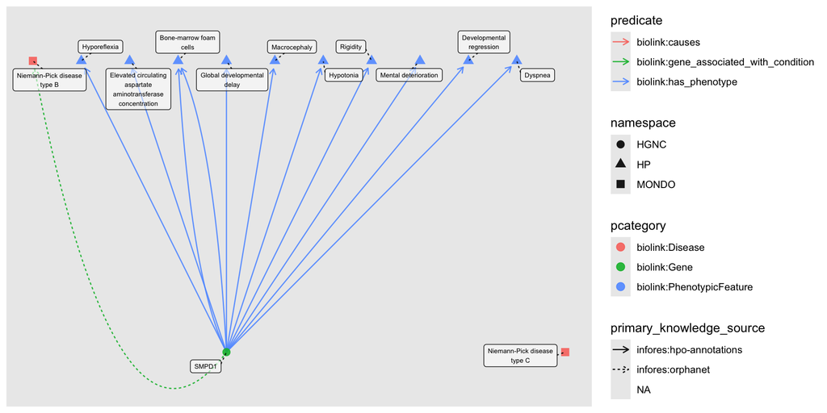

```r
# MONDO:0018982, MONDO:0011871: Neimann-Pick type B and C

g <- monarch |>
    fetch_nodes(query_ids = c("MONDO:0018982", "MONDO:0011871")) |>
    expand(predicates = c("biolink:causes", "biolink:gene_associated_with_condition")) |>
    expand(categories = c("biolink:PhenotypicFeature"), limit = 10)

plot(g)
```

We can also expand iteratively using the `expand_n` function. This allows us to grow our graph to a certain degree of distance from the original input nodes. In the below example, we begin with a graph containing the disease “MONDO:0007525” and its directly associated phenotypes.

But what if we wish to get each of the subphenotypes within each of those phenotypes? And the sub-subphenotypes of those phenotypes? We can use the `expand_n` function to iteratively get a list of descendant subphenotypes up to 3 degrees of graph distance (`n=3`). You can adjust the maximum extent of the distance by increasing/decreasing the `n` parameter.

```r
## Using example KGX file packaged with monarchr
data(eds_marfan_kg)

g <- eds_marfan_kg |>
    fetch_nodes(query_ids = "MONDO:0007525") |>
    expand(
        predicates = "biolink:has_phenotype",
        categories = "biolink:PhenotypicFeature"
    )

g_expanded <- g |> expand_n(predicates = "biolink:subclass_of", n = 3)
```

We can limit the expansion based on several factors, which are combined in an “and” fashion:

- `direction`: `"in`“, `"out"`, or `"both"` (default): which direction edges should point from the query graph nodes
- `predicates`: a character vector of edge predicates to fetch (all if unspecified)
- `categories`: a character vector of node category labels to fetch in the connected neighborhood (all if unspecified)

Lastly, the `transitive` parameter (which defaults to `FALSE`) can be used to fetch hierarchical, transitive relationships like `biolink:subclass_of`. When using `transitive = TRUE`, direction must be `"in"` or `"out"`, and `predicates` must be a single entry. The first example above illustrated this; here we explore the super-types and sub-types of Niemann-Pick, by first fetching all of its subtypes, and then considering the collective ancestry of those nodes in the KG. Not all ancestors are diseases (e.g. `biolink:Entity`), so we restrict the result set of the second expansion.

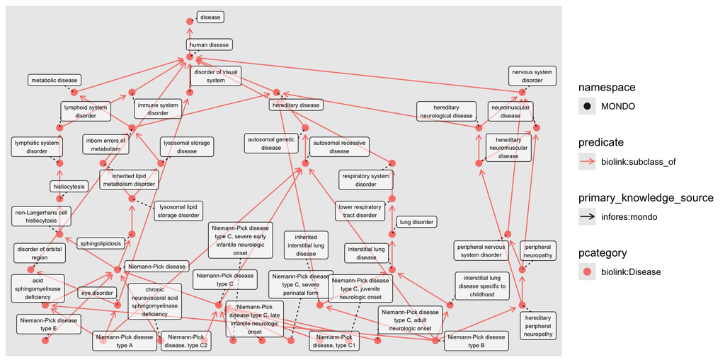

```r
# MONDO:0001982 Niemann-Pick Disease (13 subtypes)

hierarchy <- monarch |>
    fetch_nodes(query_ids = c("MONDO:0001982")) |>
    expand(predicates = "biolink:subclass_of", direction = "in", transitive = TRUE) |>
    expand(predicates = "biolink:subclass_of", direction = "out", transitive = TRUE, categories = "biolink:Disease")

plot(hierarchy)
```

# Monarch-Specific Features

While most features of `monarchr` are applicable to any KGX-formatted KG, some are specific to functionality provided by the Monarch Initiative.

## Searching

While `fetch_nodes()` and `expand()` apply to all types of engines, `monarchr` also exposes functionality specific to the Monarch Initiatives’ API services. The first of these is `monarch_search()`, which uses the same search API as the Monarch [website](https://monarchinitiative.org), returning a graph with matching nodes backed by a `monarch_engine()`.

```r
cf_hits <- monarch_search("Cystic fibrosis", category = "biolink:Disease", limit = 5)

cf_hits
```

```
Graph with 5 nodes and 0 edges. Expand sections below for details.
```

**Node Data**

Showing 5 of 5 nodes:

| id | pcategory | name | description | synonym (list) | category (list) | iri | xref (list) | namespace | provided_by | file_source | exact_synonym (list) | subsets |
| --- | --- | --- | --- | --- | --- | --- | --- | --- | --- | --- | --- | --- |
| “MONDO:0005413” | “biolink:Disease” | “cystic fibrosis associated meconium ileus” | “Cystic fibrosis associated meconium ileum is a thickening and congestion of the meconium in the ileum in newborns, often the first sign of cystic fibrosis. In cystic fibrosis, the meconium can form a… | “cystic fibrosis associated meconium ileum” | c(“biolink:Disease”, “biolink:DiseaseOrPhenotypicFeature”, “biolink:OntologyClass”, “biolink:BiologicalEntity”, “biolink:ThingWithTaxon”, “biolink:NamedThing”, “biolink:Entity”) | “http://purl.obolibrary.org/obo/MONDO_0005413” | c(“EFO:0004608”, “MEDGEN:639765”, “UMLS:C0546982”) | “MONDO” | “phenio_nodes” | “phenio_nodes” | “cystic fibrosis associated meconium ileum” | “otar” |
| “MONDO:0009061” | “biolink:Disease” | “cystic fibrosis” | “Cystic fibrosis (CF) is a genetic disorder characterized by the production of sweat with a high salt content and mucus secretions with an abnormal viscosity.” | c(“CF”, “cystic fibrosis”, “cystic fibrosis lung disease, modifier of”, “mucoviscidosis”, “pseudomonas aeruginosa, susceptibility to chronic infection by, in cystic fibrosis”) | c(“biolink:Disease”, “biolink:DiseaseOrPhenotypicFeature”, “biolink:OntologyClass”, “biolink:BiologicalEntity”, “biolink:ThingWithTaxon”, “biolink:NamedThing”, “biolink:Entity”) | “http://purl.obolibrary.org/obo/MONDO_0009061” | c(“DOID:1485”, “GARD:6233”, “ICD10CM:E84”, “ICD10WHO:E84”, “ICD9:277.0”, “MEDGEN:41393”, “MESH:D003550”, “MedDRA:10011762”, “NANDO:1200922”, “NANDO:1201021”, “NANDO:2100035”, “NANDO:2200205”, “NCIT:C2… | “MONDO” | “phenio_nodes” | “phenio_nodes” | c(“CF”, “cystic fibrosis”, “cystic fibrosis lung disease, modifier of”, “mucoviscidosis”, “pseudomonas aeruginosa, susceptibility to chronic infection by, in cystic fibrosis”) | “gard_rare\|nord_rare\|omim_susceptibility\|ordo_disorder\|orphanet_rare\|otar\|rare” |
| “MONDO:1010544” | “biolink:Disease” | “cystic fibrosis, pig” | “Cystic fibrosis that occurs in pig.” | NA | c(“biolink:Disease”, “biolink:DiseaseOrPhenotypicFeature”, “biolink:OntologyClass”, “biolink:BiologicalEntity”, “biolink:ThingWithTaxon”, “biolink:NamedThing”, “biolink:Entity”) | “http://purl.obolibrary.org/obo/MONDO_1010544” | “OMIA:001794-9823” | “MONDO” | “phenio_nodes” | “phenio_nodes” | NA | NA |
| “MONDO:1010543” | “biolink:Disease” | “cystic fibrosis, domestic ferret” | “Cystic fibrosis that occurs in domestic ferret.” | NA | c(“biolink:Disease”, “biolink:DiseaseOrPhenotypicFeature”, “biolink:OntologyClass”, “biolink:BiologicalEntity”, “biolink:ThingWithTaxon”, “biolink:NamedThing”, “biolink:Entity”) | “http://purl.obolibrary.org/obo/MONDO_1010543” | “OMIA:001794-9669” | “MONDO” | “phenio_nodes” | “phenio_nodes” | NA | NA |
| “MONDO:1010545” | “biolink:Disease” | “cystic fibrosis, sheep” | “Cystic fibrosis that occurs in sheep.” | NA | c(“biolink:Disease”, “biolink:DiseaseOrPhenotypicFeature”, “biolink:OntologyClass”, “biolink:BiologicalEntity”, “biolink:ThingWithTaxon”, “biolink:NamedThing”, “biolink:Entity”) | “http://purl.obolibrary.org/obo/MONDO_1010545” | “OMIA:001794-9940” | “MONDO” | “phenio_nodes” | “phenio_nodes” | NA | NA |

**Edge Data**

Showing 0 of 0 edges:

## Semantic Similarity

Monarch’s [Semantic Similarity](https://monarchinitiative.org/explore#phenotype-explorer) tool provides matches between given query and target nodes, based on their semantic similarity in the KG. Here we grab a few phenotypes of Ehlers-Danlos syndrome, classic type (`"MONDO:0007522"`) and Marfan Syndrome (`"MONDO:0007947"`), and we find the best matching Marfan phenotype for each EDS phenotype. The result is returned as a graph, containing only computed `"computed:best_matches"` edges:

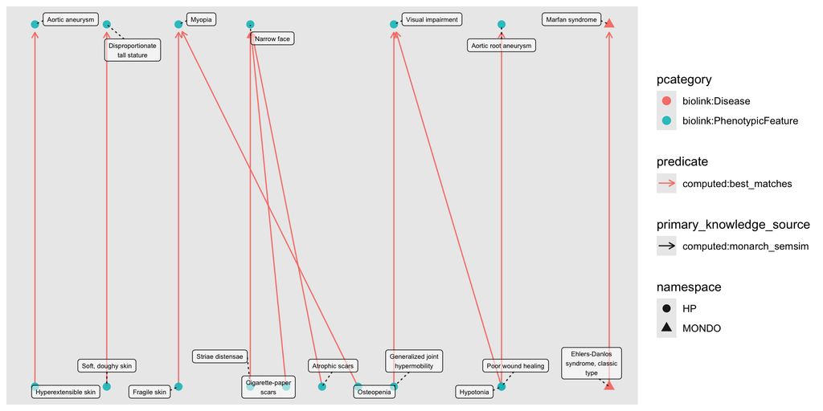

```r
eds_phenos <- monarch |>
    fetch_nodes(query_ids = "MONDO:0007522") |>
    expand(predicates = "biolink:has_phenotype", limit = 10)

marfan_phenos <- monarch |>
    fetch_nodes(query_ids = "MONDO:0007947") |>
    expand(predicates = "biolink:has_phenotype", limit = 10)

sim <- monarch_semsim(eds_phenos, marfan_phenos)

plot(sim)
```

```r
sim
```

```
Graph with 18 nodes and 11 edges. Expand sections below for details.
```

**Node Data**

Showing 18 of 18 nodes:

| id | pcategory | name | description | synonym (list) | category (list) | iri | xref (list) | file_source | namespace | provided_by | exact_synonym (list) | related_synonym (list) | subsets | narrow_synonym (list) | broad_synonym (list) |
| --- | --- | --- | --- | --- | --- | --- | --- | --- | --- | --- | --- | --- | --- | --- | --- |
| “MONDO:0007522” | “biolink:Disease” | “Ehlers-Danlos syndrome, classic type” | “Ehlers-Danlos syndrome, classic type (cEDS) is a form of Ehlers-Danlos syndrome that affects the connective tissue and is characterized by skin hyperextensibility, widened atrophic scars and joint hy… | c(“EDS I”, “EDS I, formerly”, “EDS II”, “EDS II, formerly”, “EDS, classic type”, “Ehlers Danlos syndrome, mild classic type”, “Ehlers Danlos syndrome, mild classic type, formerly”, “Ehlers Danlos synd… | c(“biolink:Disease”, “biolink:DiseaseOrPhenotypicFeature”, “biolink:OntologyClass”, “biolink:BiologicalEntity”, “biolink:ThingWithTaxon”, “biolink:NamedThing”, “biolink:Entity”) | “http://purl.obolibrary.org/obo/MONDO_0007522” | c(“GARD:2088”, “MEDGEN:909864”, “NANDO:1200646”, “NANDO:2201256”, “Orphanet:287”, “SCTID:715318006”, “UMLS:C4225429”) | “phenio_nodes” | “MONDO” | “phenio_nodes” | c(“EDS, classic type”, “Ehlers-Danlos syndrome classic type”, “Ehlers-Danlos syndrome, classic type”) | c(“EDS I”, “EDS I, formerly”, “EDS II”, “EDS II, formerly”, “Ehlers Danlos syndrome, mild classic type”, “Ehlers Danlos syndrome, mild classic type, formerly”, “Ehlers Danlos syndrome, mitis type”, “E… | “clingen\|gard_rare\|nord_rare\|ordo_disorder\|orphanet_rare\|otar\|rare” | NA | NA |
| “HP:0000974” | “biolink:PhenotypicFeature” | “Hyperextensible skin” | “A condition in which the skin can be stretched beyond normal, and then returns to its initial position.” | c(“Hyperelastic skin”, “Skin hyperelasticity”, “Skin hyperextensibility”, “Stretchable skin”) | c(“biolink:PhenotypicFeature”, “biolink:DiseaseOrPhenotypicFeature”, “biolink:OntologyClass”, “biolink:BiologicalEntity”, “biolink:ThingWithTaxon”, “biolink:NamedThing”, “biolink:Entity”) | “http://purl.obolibrary.org/obo/HP_0000974” | “UMLS:C0241074” | “phenio_nodes” | “HP” | “phenio_nodes” | c(“Hyperelastic skin”, “Skin hyperelasticity”, “Skin hyperextensibility”, “Stretchable skin”) | NA | “hposlim_core” | NA | NA |
| “HP:0001027” | “biolink:PhenotypicFeature” | “Soft, doughy skin” | “A skin texture that is unusually soft (and may feel silky), and has a malleable consistency resembling that of dough.” | “Soft, doughy skin” | c(“biolink:PhenotypicFeature”, “biolink:DiseaseOrPhenotypicFeature”, “biolink:OntologyClass”, “biolink:BiologicalEntity”, “biolink:ThingWithTaxon”, “biolink:NamedThing”, “biolink:Entity”) | “http://purl.obolibrary.org/obo/HP_0001027” | “UMLS:C1849043” | “phenio_nodes” | “HP” | “phenio_nodes” | “Soft, doughy skin” | NA | NA | NA | NA |
| “HP:0001030” | “biolink:PhenotypicFeature” | “Fragile skin” | “Skin that splits easily with minimal injury.” | c(“Fragile skin”, “Skin fragility”) | c(“biolink:PhenotypicFeature”, “biolink:DiseaseOrPhenotypicFeature”, “biolink:OntologyClass”, “biolink:BiologicalEntity”, “biolink:ThingWithTaxon”, “biolink:NamedThing”, “biolink:Entity”) | “http://purl.obolibrary.org/obo/HP_0001030” | c(“MEDDRA:10040851”, “SNOMEDCT_US:247427007”, “UMLS:C0241181”) | “phenio_nodes” | “HP” | “phenio_nodes” | c(“Fragile skin”, “Skin fragility”) | NA | “hposlim_core” | NA | NA |
| “HP:0001065” | “biolink:PhenotypicFeature” | “Striae distensae” | “Thinned, erythematous, depressed bands of atrophic skin. Initially, striae appear as flattened and thinned, pinkish linear regions of the skin. Striae tend to enlarge in length and become reddish or … | c(“Purplish striae”, “Stretch marks”, “Striae”, “Striae atrophicae”, “Striae cutis distensae”) | c(“biolink:PhenotypicFeature”, “biolink:DiseaseOrPhenotypicFeature”, “biolink:OntologyClass”, “biolink:BiologicalEntity”, “biolink:ThingWithTaxon”, “biolink:NamedThing”, “biolink:Entity”) | “http://purl.obolibrary.org/obo/HP_0001065” | c(“MEDDRA:10040925”, “SNOMEDCT_US:201066002”, “SNOMEDCT_US:201067006”, “SNOMEDCT_US:47212006”, “UMLS:C0152459”) | “phenio_nodes” | “HP” | “phenio_nodes” | c(“Purplish striae”, “Stretch marks”, “Striae”, “Striae atrophicae”, “Striae cutis distensae”) | NA | “hposlim_core” | NA | NA |
| “HP:0001073” | “biolink:PhenotypicFeature” | “Cigarette-paper scars” | “Thin (atrophic) and wide scars.” | c(“Cigarette paper scarring”, “Cigarette-paper scars”) | c(“biolink:PhenotypicFeature”, “biolink:DiseaseOrPhenotypicFeature”, “biolink:OntologyClass”, “biolink:BiologicalEntity”, “biolink:ThingWithTaxon”, “biolink:NamedThing”, “biolink:Entity”) | “http://purl.obolibrary.org/obo/HP_0001073” | “UMLS:C1851828” | “phenio_nodes” | “HP” | “phenio_nodes” | c(“Cigarette paper scarring”, “Cigarette-paper scars”) | NA | “hposlim_core” | NA | NA |
| “HP:0001075” | “biolink:PhenotypicFeature” | “Atrophic scars” | “Scars that form a depression compared to the level of the surrounding skin because of damage to the collagen, fat or other tissues below the skin.” | c(“Sunken or indented skin due to damage”, “Thin, atrophic scars”) | c(“biolink:PhenotypicFeature”, “biolink:DiseaseOrPhenotypicFeature”, “biolink:OntologyClass”, “biolink:BiologicalEntity”, “biolink:ThingWithTaxon”, “biolink:NamedThing”, “biolink:Entity”) | “http://purl.obolibrary.org/obo/HP_0001075” | c(“SNOMEDCT_US:239172000”, “SNOMEDCT_US:409766009”, “UMLS:C0162154”) | “phenio_nodes” | “HP” | “phenio_nodes” | c(“Sunken or indented skin due to damage”, “Thin, atrophic scars”) | NA | “hposlim_core” | NA | NA |
| “HP:0002761” | “biolink:PhenotypicFeature” | “Generalized joint hypermobility” | “Joint hypermobility (ability of a joint to move beyond its normal range of motion) affecting many or all joints of the body. In individuals with Joint hypermobility at multiple sites (usually five or… | c(“Generalised joint laxity”, “Generalized joint laxity”, “Hypermobility of all joints”, “Joint laxity, generalised”, “Joint laxity, generalized”) | c(“biolink:PhenotypicFeature”, “biolink:DiseaseOrPhenotypicFeature”, “biolink:OntologyClass”, “biolink:BiologicalEntity”, “biolink:ThingWithTaxon”, “biolink:NamedThing”, “biolink:Entity”) | “http://purl.obolibrary.org/obo/HP_0002761” | “UMLS:C1836308” | “phenio_nodes” | “HP” | “phenio_nodes” | c(“Generalised joint laxity”, “Generalized joint laxity”, “Hypermobility of all joints”) | c(“Joint laxity, generalised”, “Joint laxity, generalized”) | NA | NA | NA |
| “HP:0000938” | “biolink:PhenotypicFeature” | “Osteopenia” | “Osteopenia is a term to define bone density that is not normal but also not as low as osteoporosis. By definition from the World Health Organization osteopenia is defined by bone densitometry as a T … | c(“Generalised osteopenia”, “Generalized osteopenia”, “Osteopaenia”) | c(“biolink:PhenotypicFeature”, “biolink:DiseaseOrPhenotypicFeature”, “biolink:OntologyClass”, “biolink:BiologicalEntity”, “biolink:ThingWithTaxon”, “biolink:NamedThing”, “biolink:Entity”) | “http://purl.obolibrary.org/obo/HP_0000938” | c(“SNOMEDCT_US:312894000”, “SNOMEDCT_US:78441005”, “UMLS:C0029453”, “UMLS:C0747078”) | “phenio_nodes” | “HP” | “phenio_nodes” | c(“Generalised osteopenia”, “Generalized osteopenia”, “Osteopaenia”) | NA | NA | NA | NA |
| “HP:0001058” | “biolink:PhenotypicFeature” | “Poor wound healing” | “A reduced ability to heal cutaneous wounds.” | “Poor wound healing” | c(“biolink:PhenotypicFeature”, “biolink:DiseaseOrPhenotypicFeature”, “biolink:OntologyClass”, “biolink:BiologicalEntity”, “biolink:ThingWithTaxon”, “biolink:NamedThing”, “biolink:Entity”) | “http://purl.obolibrary.org/obo/HP_0001058” | “UMLS:C1851789” | “phenio_nodes” | “HP” | “phenio_nodes” | “Poor wound healing” | NA | “hposlim_core” | NA | NA |
| “HP:0001252” | “biolink:PhenotypicFeature” | “Hypotonia” | “Hypotonia is an abnormally low muscle tone (the amount of tension or resistance to movement in a muscle). Even when relaxed, muscles have a continuous and passive partial contraction which provides s… | c(“Central hypotonia”, “Low muscle tone”, “Low or weak muscle tone”, “Muscle hypotonia”, “Muscular hypotonia”, “Peripheral hypotonia”) | c(“biolink:PhenotypicFeature”, “biolink:DiseaseOrPhenotypicFeature”, “biolink:OntologyClass”, “biolink:BiologicalEntity”, “biolink:ThingWithTaxon”, “biolink:NamedThing”, “biolink:Entity”) | “http://purl.obolibrary.org/obo/HP_0001252” | c(“SNOMEDCT_US:398151007”, “SNOMEDCT_US:398152000”, “UMLS:C0026827”) | “phenio_nodes” | “HP” | “phenio_nodes” | c(“Low muscle tone”, “Low or weak muscle tone”, “Muscle hypotonia”, “Muscular hypotonia”) | NA | NA | c(“Central hypotonia”, “Peripheral hypotonia”) | NA |
| “MONDO:0007947” | “biolink:Disease” | “Marfan syndrome” | “A disorder of the connective tissue. Connective tissue provides strength and flexibility to structures throughout the body such as bones, ligaments, muscles, walls of blood vessels, and heart valves.… | c(“MFS”, “MFS1”, “Marfan syndrome”, “Marfan syndrome type 1”, “Marfan syndrome, type 1”, “Marfan’s syndrome”) | c(“biolink:Disease”, “biolink:DiseaseOrPhenotypicFeature”, “biolink:OntologyClass”, “biolink:BiologicalEntity”, “biolink:ThingWithTaxon”, “biolink:NamedThing”, “biolink:Entity”) | “http://purl.obolibrary.org/obo/MONDO_0007947” | c(“DOID:14323”, “GARD:16535”, “ICD10CM:Q87.4”, “ICD9:759.82”, “MEDGEN:44287”, “MESH:D008382”, “MedDRA:10026829”, “NANDO:1200644”, “NANDO:2200968”, “NCIT:C34807”, “NORD:1403”, “OMIM:154700”, “Orphanet:… | “phenio_nodes” | “MONDO” | “phenio_nodes” | c(“MFS”, “MFS1”, “Marfan syndrome”, “Marfan syndrome type 1”, “Marfan syndrome, type 1”, “Marfan’s syndrome”) | NA | “clingen\|gard_rare\|nord_rare\|ordo_disorder\|ordo_subtype_of_a_disorder\|orphanet_rare\|otar\|prototype_pattern\|rare” | NA | NA |
| “HP:0001519” | “biolink:PhenotypicFeature” | “Disproportionate tall stature” | “A tall and slim body build with increased arm span to height ratio (>1.05) and a reduced upper-to-lower segment ratio ( | c(“Dolichostenomelia”, “Marfanoid body habitus”, “Marfanoid habitus”, “Reduced upper-lower segment ratio”) | c(“biolink:PhenotypicFeature”, “biolink:DiseaseOrPhenotypicFeature”, “biolink:OntologyClass”, “biolink:BiologicalEntity”, “biolink:ThingWithTaxon”, “biolink:NamedThing”, “biolink:Entity”) | “http://purl.obolibrary.org/obo/HP_0001519” | c(“SNOMEDCT_US:62250003”, “UMLS:C0003706”, “UMLS:C1836996”) | “phenio_nodes” | “HP” | “phenio_nodes” | c(“Dolichostenomelia”, “Marfanoid body habitus”, “Marfanoid habitus”, “Reduced upper-lower segment ratio”) | NA | NA | NA | NA |
| “HP:0002616” | “biolink:PhenotypicFeature” | “Aortic root aneurysm” | “An abnormal localized widening (dilatation) of the aortic root.” | c(“Aortic root dilatation”, “Bulge in wall of root of large artery that carries blood away from heart”, “Enlarged aortic root”, “Increased aortic root diameter”) | c(“biolink:PhenotypicFeature”, “biolink:DiseaseOrPhenotypicFeature”, “biolink:OntologyClass”, “biolink:BiologicalEntity”, “biolink:ThingWithTaxon”, “biolink:NamedThing”, “biolink:Entity”) | “http://purl.obolibrary.org/obo/HP_0002616” | c(“SNOMEDCT_US:251036003”, “UMLS:C0238669”) | “phenio_nodes” | “HP” | “phenio_nodes” | c(“Bulge in wall of root of large artery that carries blood away from heart”, “Enlarged aortic root”, “Increased aortic root diameter”) | NA | NA | NA | “Aortic root dilatation” |
| “HP:0004942” | “biolink:PhenotypicFeature” | “Aortic aneurysm” | “Aortic dilatation refers to a dimension that is greater than the 95th percentile for the normal person age, sex and body size. In contrast, an aneurysm is defined as a localized dilation of the aorta… | c(“Aortic dilatation”, “Bulge in wall of large artery that carries blood away from heart”, “Enlarged aorta”) | c(“biolink:PhenotypicFeature”, “biolink:DiseaseOrPhenotypicFeature”, “biolink:OntologyClass”, “biolink:BiologicalEntity”, “biolink:ThingWithTaxon”, “biolink:NamedThing”, “biolink:Entity”) | “http://purl.obolibrary.org/obo/HP_0004942” | c(“Fyler:2301”, “Fyler:2708”, “SNOMEDCT_US:67362008”, “UMLS:C0003486”) | “phenio_nodes” | “HP” | “phenio_nodes” | c(“Aortic dilatation”, “Bulge in wall of large artery that carries blood away from heart”, “Enlarged aorta”) | NA | NA | NA | NA |
| “HP:0000275” | “biolink:PhenotypicFeature” | “Narrow face” | “Bizygomatic (upper face) and bigonial (lower face) width are both more than 2 standard deviations below the mean (objective); or, an apparent reduction in the width of the upper and lower face (subje… | c(“Decreased breadth of face”, “Decreased horizontal dimension of face”, “Decreased transverse dimension of face”, “Decreased width of face”, “Horizontal deficiency of face”, “Horizontal hypoplasia of… | c(“biolink:PhenotypicFeature”, “biolink:DiseaseOrPhenotypicFeature”, “biolink:OntologyClass”, “biolink:BiologicalEntity”, “biolink:ThingWithTaxon”, “biolink:NamedThing”, “biolink:Entity”) | “http://purl.obolibrary.org/obo/HP_0000275” | c(“UMLS:C1837463”, “UMLS:C1849121”) | “phenio_nodes” | “HP” | “phenio_nodes” | c(“Decreased breadth of face”, “Decreased horizontal dimension of face”, “Decreased transverse dimension of face”, “Decreased width of face”, “Horizontal deficiency of face”, “Horizontal hypoplasia of… | “Thin face” | “hposlim_core” | NA | NA |
| “HP:0000505” | “biolink:PhenotypicFeature” | “Visual impairment” | “Visual impairment (or vision impairment) is vision loss (of a person) to such a degree as to qualify as an additional support need through a significant limitation of visual capability resulting from… | c(“Impaired vision”, “Loss of eyesight”, “Poor vision”, “Visual impairment”) | c(“biolink:PhenotypicFeature”, “biolink:DiseaseOrPhenotypicFeature”, “biolink:OntologyClass”, “biolink:BiologicalEntity”, “biolink:ThingWithTaxon”, “biolink:NamedThing”, “biolink:Entity”) | “http://purl.obolibrary.org/obo/HP_0000505” | c(“SNOMEDCT_US:246635007”, “SNOMEDCT_US:397540003”, “SNOMEDCT_US:7973008”, “UMLS:C0042798”, “UMLS:C3665347”) | “phenio_nodes” | “HP” | “phenio_nodes” | c(“Impaired vision”, “Loss of eyesight”, “Poor vision”, “Visual impairment”) | NA | “hposlim_core” | NA | NA |
| “HP:0000545” | “biolink:PhenotypicFeature” | “Myopia” | “An abnormality of refraction characterized by the ability to see objects nearby clearly, while objects in the distance appear blurry.” | c(“Close sighted”, “Near sighted”, “Near sightedness”, “Nearsightedness”) | c(“biolink:PhenotypicFeature”, “biolink:DiseaseOrPhenotypicFeature”, “biolink:OntologyClass”, “biolink:BiologicalEntity”, “biolink:ThingWithTaxon”, “biolink:NamedThing”, “biolink:Entity”) | “http://purl.obolibrary.org/obo/HP_0000545” | c(“SNOMEDCT_US:57190000”, “UMLS:C0027092”) | “phenio_nodes” | “HP” | “phenio_nodes” | c(“Close sighted”, “Near sighted”, “Near sightedness”, “Nearsightedness”) | NA | “hposlim_core” | NA | NA |

**Edge Data**

Showing 11 of 11 edges:

| from | to | subject | predicate | object | primary_knowledge_source | monarch_semsim_metric | monarch_semsim_score | monarch_semsim_ancestor_id |
| --- | --- | --- | --- | --- | --- | --- | --- | --- |
| 9 | 18 | “HP:0000938” | “computed:best_matches” | “HP:0000545” | “computed:monarch_semsim” | “ancestor_information_content” | 6.70680342148165 | “UPHENO:0002308” |
| 2 | 15 | “HP:0000974” | “computed:best_matches” | “HP:0004942” | “computed:monarch_semsim” | “ancestor_information_content” | 4.46371918643524 | “HP:0000118” |
| 3 | 13 | “HP:0001027” | “computed:best_matches” | “HP:0001519” | “computed:monarch_semsim” | “ancestor_information_content” | 4.46371918643524 | “HP:0000118” |
| 4 | 18 | “HP:0001030” | “computed:best_matches” | “HP:0000545” | “computed:monarch_semsim” | “ancestor_information_content” | 4.46371918643524 | “HP:0000118” |
| 10 | 14 | “HP:0001058” | “computed:best_matches” | “HP:0002616” | “computed:monarch_semsim” | “ancestor_information_content” | 4.46371918643524 | “HP:0000118” |
| 5 | 16 | “HP:0001065” | “computed:best_matches” | “HP:0000275” | “computed:monarch_semsim” | “ancestor_information_content” | 6.25789977823653 | “UPHENO:0069327” |
| 6 | 16 | “HP:0001073” | “computed:best_matches” | “HP:0000275” | “computed:monarch_semsim” | “ancestor_information_content” | 6.25789977823653 | “UPHENO:0069327” |
| 7 | 16 | “HP:0001075” | “computed:best_matches” | “HP:0000275” | “computed:monarch_semsim” | “ancestor_information_content” | 6.25789977823653 | “UPHENO:0069327” |
| 11 | 17 | “HP:0001252” | “computed:best_matches” | “HP:0000505” | “computed:monarch_semsim” | “ancestor_information_content” | 7.50929753749366 | “UPHENO:0002386” |
| 8 | 17 | “HP:0002761” | “computed:best_matches” | “HP:0000505” | “computed:monarch_semsim” | “ancestor_information_content” | 6.70680342148165 | “UPHENO:0002308” |
| 1 | 12 | “MONDO:0007522” | “computed:best_matches” | “MONDO:0007947” | “computed:monarch_semsim” | “ancestor_information_content” | 9.21101965131109 | “MONDO:0000426” |

Note that the Disease nodes were included in the match as well. Although not displayed by `plot()`, edges also include the metric, similarity score, and ID of the least common ancestor relating the nodes.

We can use `tidygraph`’s `graph_join()` to see this result in the context of the original query and target graphs.

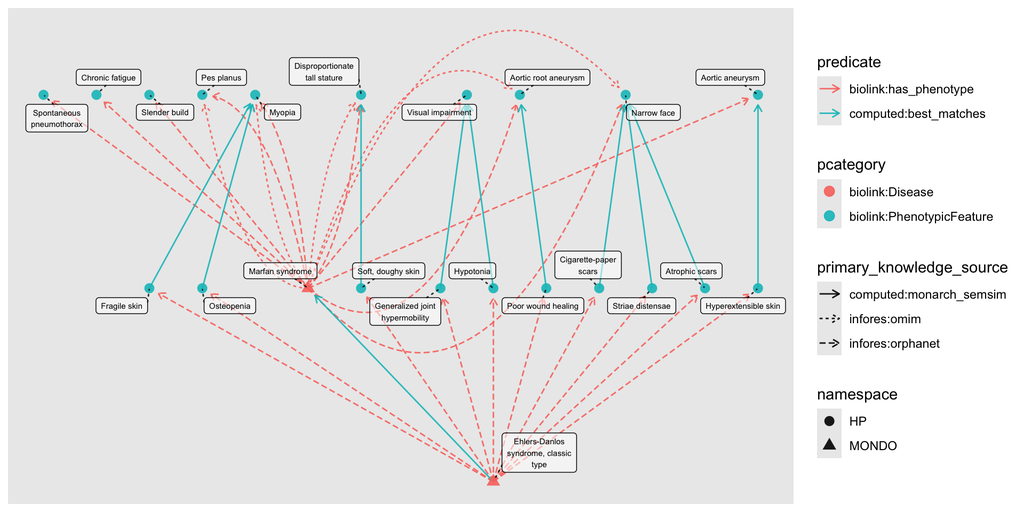

```r
both_phenos <- eds_phenos |>
    graph_join(marfan_phenos) |>
    graph_join(sim)

plot(both_phenos)
```

```r
both_phenos
```

```
Graph with 22 nodes and 36 edges. Expand sections below for details.
```

**Node Data**

Showing 22 of 22 nodes:

| id | pcategory | name | description | synonym (list) | category (list) | iri | xref (list) | file_source | namespace | provided_by | exact_synonym (list) | related_synonym (list) | subsets | narrow_synonym (list) | broad_synonym (list) |
| --- | --- | --- | --- | --- | --- | --- | --- | --- | --- | --- | --- | --- | --- | --- | --- |
| “MONDO:0007522” | “biolink:Disease” | “Ehlers-Danlos syndrome, classic type” | “Ehlers-Danlos syndrome, classic type (cEDS) is a form of Ehlers-Danlos syndrome that affects the connective tissue and is characterized by skin hyperextensibility, widened atrophic scars and joint hy… | c(“EDS I”, “EDS I, formerly”, “EDS II”, “EDS II, formerly”, “EDS, classic type”, “Ehlers Danlos syndrome, mild classic type”, “Ehlers Danlos syndrome, mild classic type, formerly”, “Ehlers Danlos synd… | c(“biolink:Disease”, “biolink:DiseaseOrPhenotypicFeature”, “biolink:OntologyClass”, “biolink:BiologicalEntity”, “biolink:ThingWithTaxon”, “biolink:NamedThing”, “biolink:Entity”) | “http://purl.obolibrary.org/obo/MONDO_0007522” | c(“GARD:2088”, “MEDGEN:909864”, “NANDO:1200646”, “NANDO:2201256”, “Orphanet:287”, “SCTID:715318006”, “UMLS:C4225429”) | “phenio_nodes” | “MONDO” | “phenio_nodes” | c(“EDS, classic type”, “Ehlers-Danlos syndrome classic type”, “Ehlers-Danlos syndrome, classic type”) | c(“EDS I”, “EDS I, formerly”, “EDS II”, “EDS II, formerly”, “Ehlers Danlos syndrome, mild classic type”, “Ehlers Danlos syndrome, mild classic type, formerly”, “Ehlers Danlos syndrome, mitis type”, “E… | “clingen\|gard_rare\|nord_rare\|ordo_disorder\|orphanet_rare\|otar\|rare” | NA | NA |
| “HP:0000974” | “biolink:PhenotypicFeature” | “Hyperextensible skin” | “A condition in which the skin can be stretched beyond normal, and then returns to its initial position.” | c(“Hyperelastic skin”, “Skin hyperelasticity”, “Skin hyperextensibility”, “Stretchable skin”) | c(“biolink:PhenotypicFeature”, “biolink:DiseaseOrPhenotypicFeature”, “biolink:OntologyClass”, “biolink:BiologicalEntity”, “biolink:ThingWithTaxon”, “biolink:NamedThing”, “biolink:Entity”) | “http://purl.obolibrary.org/obo/HP_0000974” | “UMLS:C0241074” | “phenio_nodes” | “HP” | “phenio_nodes” | c(“Hyperelastic skin”, “Skin hyperelasticity”, “Skin hyperextensibility”, “Stretchable skin”) | NA | “hposlim_core” | NA | NA |
| “HP:0001027” | “biolink:PhenotypicFeature” | “Soft, doughy skin” | “A skin texture that is unusually soft (and may feel silky), and has a malleable consistency resembling that of dough.” | “Soft, doughy skin” | c(“biolink:PhenotypicFeature”, “biolink:DiseaseOrPhenotypicFeature”, “biolink:OntologyClass”, “biolink:BiologicalEntity”, “biolink:ThingWithTaxon”, “biolink:NamedThing”, “biolink:Entity”) | “http://purl.obolibrary.org/obo/HP_0001027” | “UMLS:C1849043” | “phenio_nodes” | “HP” | “phenio_nodes” | “Soft, doughy skin” | NA | NA | NA | NA |
| “HP:0001030” | “biolink:PhenotypicFeature” | “Fragile skin” | “Skin that splits easily with minimal injury.” | c(“Fragile skin”, “Skin fragility”) | c(“biolink:PhenotypicFeature”, “biolink:DiseaseOrPhenotypicFeature”, “biolink:OntologyClass”, “biolink:BiologicalEntity”, “biolink:ThingWithTaxon”, “biolink:NamedThing”, “biolink:Entity”) | “http://purl.obolibrary.org/obo/HP_0001030” | c(“MEDDRA:10040851”, “SNOMEDCT_US:247427007”, “UMLS:C0241181”) | “phenio_nodes” | “HP” | “phenio_nodes” | c(“Fragile skin”, “Skin fragility”) | NA | “hposlim_core” | NA | NA |
| “HP:0001065” | “biolink:PhenotypicFeature” | “Striae distensae” | “Thinned, erythematous, depressed bands of atrophic skin. Initially, striae appear as flattened and thinned, pinkish linear regions of the skin. Striae tend to enlarge in length and become reddish or … | c(“Purplish striae”, “Stretch marks”, “Striae”, “Striae atrophicae”, “Striae cutis distensae”) | c(“biolink:PhenotypicFeature”, “biolink:DiseaseOrPhenotypicFeature”, “biolink:OntologyClass”, “biolink:BiologicalEntity”, “biolink:ThingWithTaxon”, “biolink:NamedThing”, “biolink:Entity”) | “http://purl.obolibrary.org/obo/HP_0001065” | c(“MEDDRA:10040925”, “SNOMEDCT_US:201066002”, “SNOMEDCT_US:201067006”, “SNOMEDCT_US:47212006”, “UMLS:C0152459”) | “phenio_nodes” | “HP” | “phenio_nodes” | c(“Purplish striae”, “Stretch marks”, “Striae”, “Striae atrophicae”, “Striae cutis distensae”) | NA | “hposlim_core” | NA | NA |
| “HP:0001073” | “biolink:PhenotypicFeature” | “Cigarette-paper scars” | “Thin (atrophic) and wide scars.” | c(“Cigarette paper scarring”, “Cigarette-paper scars”) | c(“biolink:PhenotypicFeature”, “biolink:DiseaseOrPhenotypicFeature”, “biolink:OntologyClass”, “biolink:BiologicalEntity”, “biolink:ThingWithTaxon”, “biolink:NamedThing”, “biolink:Entity”) | “http://purl.obolibrary.org/obo/HP_0001073” | “UMLS:C1851828” | “phenio_nodes” | “HP” | “phenio_nodes” | c(“Cigarette paper scarring”, “Cigarette-paper scars”) | NA | “hposlim_core” | NA | NA |
| “HP:0001075” | “biolink:PhenotypicFeature” | “Atrophic scars” | “Scars that form a depression compared to the level of the surrounding skin because of damage to the collagen, fat or other tissues below the skin.” | c(“Sunken or indented skin due to damage”, “Thin, atrophic scars”) | c(“biolink:PhenotypicFeature”, “biolink:DiseaseOrPhenotypicFeature”, “biolink:OntologyClass”, “biolink:BiologicalEntity”, “biolink:ThingWithTaxon”, “biolink:NamedThing”, “biolink:Entity”) | “http://purl.obolibrary.org/obo/HP_0001075” | c(“SNOMEDCT_US:239172000”, “SNOMEDCT_US:409766009”, “UMLS:C0162154”) | “phenio_nodes” | “HP” | “phenio_nodes” | c(“Sunken or indented skin due to damage”, “Thin, atrophic scars”) | NA | “hposlim_core” | NA | NA |
| “HP:0002761” | “biolink:PhenotypicFeature” | “Generalized joint hypermobility” | “Joint hypermobility (ability of a joint to move beyond its normal range of motion) affecting many or all joints of the body. In individuals with Joint hypermobility at multiple sites (usually five or… | c(“Generalised joint laxity”, “Generalized joint laxity”, “Hypermobility of all joints”, “Joint laxity, generalised”, “Joint laxity, generalized”) | c(“biolink:PhenotypicFeature”, “biolink:DiseaseOrPhenotypicFeature”, “biolink:OntologyClass”, “biolink:BiologicalEntity”, “biolink:ThingWithTaxon”, “biolink:NamedThing”, “biolink:Entity”) | “http://purl.obolibrary.org/obo/HP_0002761” | “UMLS:C1836308” | “phenio_nodes” | “HP” | “phenio_nodes” | c(“Generalised joint laxity”, “Generalized joint laxity”, “Hypermobility of all joints”) | c(“Joint laxity, generalised”, “Joint laxity, generalized”) | NA | NA | NA |
| “HP:0000938” | “biolink:PhenotypicFeature” | “Osteopenia” | “Osteopenia is a term to define bone density that is not normal but also not as low as osteoporosis. By definition from the World Health Organization osteopenia is defined by bone densitometry as a T … | c(“Generalised osteopenia”, “Generalized osteopenia”, “Osteopaenia”) | c(“biolink:PhenotypicFeature”, “biolink:DiseaseOrPhenotypicFeature”, “biolink:OntologyClass”, “biolink:BiologicalEntity”, “biolink:ThingWithTaxon”, “biolink:NamedThing”, “biolink:Entity”) | “http://purl.obolibrary.org/obo/HP_0000938” | c(“SNOMEDCT_US:312894000”, “SNOMEDCT_US:78441005”, “UMLS:C0029453”, “UMLS:C0747078”) | “phenio_nodes” | “HP” | “phenio_nodes” | c(“Generalised osteopenia”, “Generalized osteopenia”, “Osteopaenia”) | NA | NA | NA | NA |
| “HP:0001058” | “biolink:PhenotypicFeature” | “Poor wound healing” | “A reduced ability to heal cutaneous wounds.” | “Poor wound healing” | c(“biolink:PhenotypicFeature”, “biolink:DiseaseOrPhenotypicFeature”, “biolink:OntologyClass”, “biolink:BiologicalEntity”, “biolink:ThingWithTaxon”, “biolink:NamedThing”, “biolink:Entity”) | “http://purl.obolibrary.org/obo/HP_0001058” | “UMLS:C1851789” | “phenio_nodes” | “HP” | “phenio_nodes” | “Poor wound healing” | NA | “hposlim_core” | NA | NA |
| “HP:0001252” | “biolink:PhenotypicFeature” | “Hypotonia” | “Hypotonia is an abnormally low muscle tone (the amount of tension or resistance to movement in a muscle). Even when relaxed, muscles have a continuous and passive partial contraction which provides s… | c(“Central hypotonia”, “Low muscle tone”, “Low or weak muscle tone”, “Muscle hypotonia”, “Muscular hypotonia”, “Peripheral hypotonia”) | c(“biolink:PhenotypicFeature”, “biolink:DiseaseOrPhenotypicFeature”, “biolink:OntologyClass”, “biolink:BiologicalEntity”, “biolink:ThingWithTaxon”, “biolink:NamedThing”, “biolink:Entity”) | “http://purl.obolibrary.org/obo/HP_0001252” | c(“SNOMEDCT_US:398151007”, “SNOMEDCT_US:398152000”, “UMLS:C0026827”) | “phenio_nodes” | “HP” | “phenio_nodes” | c(“Low muscle tone”, “Low or weak muscle tone”, “Muscle hypotonia”, “Muscular hypotonia”) | NA | NA | c(“Central hypotonia”, “Peripheral hypotonia”) | NA |
| “MONDO:0007947” | “biolink:Disease” | “Marfan syndrome” | “A disorder of the connective tissue. Connective tissue provides strength and flexibility to structures throughout the body such as bones, ligaments, muscles, walls of blood vessels, and heart valves.… | c(“MFS”, “MFS1”, “Marfan syndrome”, “Marfan syndrome type 1”, “Marfan syndrome, type 1”, “Marfan’s syndrome”) | c(“biolink:Disease”, “biolink:DiseaseOrPhenotypicFeature”, “biolink:OntologyClass”, “biolink:BiologicalEntity”, “biolink:ThingWithTaxon”, “biolink:NamedThing”, “biolink:Entity”) | “http://purl.obolibrary.org/obo/MONDO_0007947” | c(“DOID:14323”, “GARD:16535”, “ICD10CM:Q87.4”, “ICD9:759.82”, “MEDGEN:44287”, “MESH:D008382”, “MedDRA:10026829”, “NANDO:1200644”, “NANDO:2200968”, “NCIT:C34807”, “NORD:1403”, “OMIM:154700”, “Orphanet:… | “phenio_nodes” | “MONDO” | “phenio_nodes” | c(“MFS”, “MFS1”, “Marfan syndrome”, “Marfan syndrome type 1”, “Marfan syndrome, type 1”, “Marfan’s syndrome”) | NA | “clingen\|gard_rare\|nord_rare\|ordo_disorder\|ordo_subtype_of_a_disorder\|orphanet_rare\|otar\|prototype_pattern\|rare” | NA | NA |
| “HP:0001519” | “biolink:PhenotypicFeature” | “Disproportionate tall stature” | “A tall and slim body build with increased arm span to height ratio (>1.05) and a reduced upper-to-lower segment ratio ( | c(“Dolichostenomelia”, “Marfanoid body habitus”, “Marfanoid habitus”, “Reduced upper-lower segment ratio”) | c(“biolink:PhenotypicFeature”, “biolink:DiseaseOrPhenotypicFeature”, “biolink:OntologyClass”, “biolink:BiologicalEntity”, “biolink:ThingWithTaxon”, “biolink:NamedThing”, “biolink:Entity”) | “http://purl.obolibrary.org/obo/HP_0001519” | c(“SNOMEDCT_US:62250003”, “UMLS:C0003706”, “UMLS:C1836996”) | “phenio_nodes” | “HP” | “phenio_nodes” | c(“Dolichostenomelia”, “Marfanoid body habitus”, “Marfanoid habitus”, “Reduced upper-lower segment ratio”) | NA | NA | NA | NA |
| “HP:0001533” | “biolink:PhenotypicFeature” | “Slender build” | “Asthenic habitus refers to a slender build with long limbs, an angular profile, and prominent muscles or bones.” | c(“Asthenic habitus”, “Slender build”, “Thin body habitus”, “Thin build”) | c(“biolink:PhenotypicFeature”, “biolink:DiseaseOrPhenotypicFeature”, “biolink:OntologyClass”, “biolink:BiologicalEntity”, “biolink:ThingWithTaxon”, “biolink:NamedThing”, “biolink:Entity”) | “http://purl.obolibrary.org/obo/HP_0001533” | “UMLS:C1850573” | “phenio_nodes” | “HP” | “phenio_nodes” | c(“Asthenic habitus”, “Slender build”, “Thin body habitus”, “Thin build”) | NA | NA | NA | NA |
| “HP:0001763” | “biolink:PhenotypicFeature” | “Pes planus” | “A foot where the longitudinal arch of the foot is in contact with the ground or floor when the individual is standing; or, in a patient lying supine, a foot where the arch is in contact with the surf… | c(“Dropped arches”, “Fallen arches”, “Flat feet”, “Flat foot”) | c(“biolink:PhenotypicFeature”, “biolink:DiseaseOrPhenotypicFeature”, “biolink:OntologyClass”, “biolink:BiologicalEntity”, “biolink:ThingWithTaxon”, “biolink:NamedThing”, “biolink:Entity”) | “http://purl.obolibrary.org/obo/HP_0001763” | c(“SNOMEDCT_US:203534009”, “SNOMEDCT_US:53226007”, “UMLS:C0016202”, “UMLS:C0264133”) | “phenio_nodes” | “HP” | “phenio_nodes” | c(“Flat feet”, “Flat foot”) | c(“Dropped arches”, “Fallen arches”) | “hposlim_core” | NA | NA |
| “HP:0002108” | “biolink:PhenotypicFeature” | “Spontaneous pneumothorax” | “Pneumothorax occurring without traumatic injury to the chest or lung.” | “Spontaneous collapsed lung” | c(“biolink:PhenotypicFeature”, “biolink:DiseaseOrPhenotypicFeature”, “biolink:OntologyClass”, “biolink:BiologicalEntity”, “biolink:ThingWithTaxon”, “biolink:NamedThing”, “biolink:Entity”) | “http://purl.obolibrary.org/obo/HP_0002108” | c(“SNOMEDCT_US:80423007”, “UMLS:C0149781”) | “phenio_nodes” | “HP” | “phenio_nodes” | “Spontaneous collapsed lung” | NA | NA | NA | NA |
| “HP:0002616” | “biolink:PhenotypicFeature” | “Aortic root aneurysm” | “An abnormal localized widening (dilatation) of the aortic root.” | c(“Aortic root dilatation”, “Bulge in wall of root of large artery that carries blood away from heart”, “Enlarged aortic root”, “Increased aortic root diameter”) | c(“biolink:PhenotypicFeature”, “biolink:DiseaseOrPhenotypicFeature”, “biolink:OntologyClass”, “biolink:BiologicalEntity”, “biolink:ThingWithTaxon”, “biolink:NamedThing”, “biolink:Entity”) | “http://purl.obolibrary.org/obo/HP_0002616” | c(“SNOMEDCT_US:251036003”, “UMLS:C0238669”) | “phenio_nodes” | “HP” | “phenio_nodes” | c(“Bulge in wall of root of large artery that carries blood away from heart”, “Enlarged aortic root”, “Increased aortic root diameter”) | NA | NA | NA | “Aortic root dilatation” |
| “HP:0004942” | “biolink:PhenotypicFeature” | “Aortic aneurysm” | “Aortic dilatation refers to a dimension that is greater than the 95th percentile for the normal person age, sex and body size. In contrast, an aneurysm is defined as a localized dilation of the aorta… | c(“Aortic dilatation”, “Bulge in wall of large artery that carries blood away from heart”, “Enlarged aorta”) | c(“biolink:PhenotypicFeature”, “biolink:DiseaseOrPhenotypicFeature”, “biolink:OntologyClass”, “biolink:BiologicalEntity”, “biolink:ThingWithTaxon”, “biolink:NamedThing”, “biolink:Entity”) | “http://purl.obolibrary.org/obo/HP_0004942” | c(“Fyler:2301”, “Fyler:2708”, “SNOMEDCT_US:67362008”, “UMLS:C0003486”) | “phenio_nodes” | “HP” | “phenio_nodes” | c(“Aortic dilatation”, “Bulge in wall of large artery that carries blood away from heart”, “Enlarged aorta”) | NA | NA | NA | NA |
| “HP:0012432” | “biolink:PhenotypicFeature” | “Chronic fatigue” | “Subjective feeling of tiredness characterized by a lack of energy and motivation that persists for six months or longer.” | c(“Chronic extreme exhaustion”, “Chronic fatigue”) | c(“biolink:PhenotypicFeature”, “biolink:DiseaseOrPhenotypicFeature”, “biolink:OntologyClass”, “biolink:BiologicalEntity”, “biolink:ThingWithTaxon”, “biolink:NamedThing”, “biolink:Entity”) | “http://purl.obolibrary.org/obo/HP_0012432” | “UMLS:C0518656” | “phenio_nodes” | “HP” | “phenio_nodes” | c(“Chronic extreme exhaustion”, “Chronic fatigue”) | NA | NA | NA | NA |
| “HP:0000275” | “biolink:PhenotypicFeature” | “Narrow face” | “Bizygomatic (upper face) and bigonial (lower face) width are both more than 2 standard deviations below the mean (objective); or, an apparent reduction in the width of the upper and lower face (subje… | c(“Decreased breadth of face”, “Decreased horizontal dimension of face”, “Decreased transverse dimension of face”, “Decreased width of face”, “Horizontal deficiency of face”, “Horizontal hypoplasia of… | c(“biolink:PhenotypicFeature”, “biolink:DiseaseOrPhenotypicFeature”, “biolink:OntologyClass”, “biolink:BiologicalEntity”, “biolink:ThingWithTaxon”, “biolink:NamedThing”, “biolink:Entity”) | “http://purl.obolibrary.org/obo/HP_0000275” | c(“UMLS:C1837463”, “UMLS:C1849121”) | “phenio_nodes” | “HP” | “phenio_nodes” | c(“Decreased breadth of face”, “Decreased horizontal dimension of face”, “Decreased transverse dimension of face”, “Decreased width of face”, “Horizontal deficiency of face”, “Horizontal hypoplasia of… | “Thin face” | “hposlim_core” | NA | NA |
| “HP:0000505” | “biolink:PhenotypicFeature” | “Visual impairment” | “Visual impairment (or vision impairment) is vision loss (of a person) to such a degree as to qualify as an additional support need through a significant limitation of visual capability resulting from… | c(“Impaired vision”, “Loss of eyesight”, “Poor vision”, “Visual impairment”) | c(“biolink:PhenotypicFeature”, “biolink:DiseaseOrPhenotypicFeature”, “biolink:OntologyClass”, “biolink:BiologicalEntity”, “biolink:ThingWithTaxon”, “biolink:NamedThing”, “biolink:Entity”) | “http://purl.obolibrary.org/obo/HP_0000505” | c(“SNOMEDCT_US:246635007”, “SNOMEDCT_US:397540003”, “SNOMEDCT_US:7973008”, “UMLS:C0042798”, “UMLS:C3665347”) | “phenio_nodes” | “HP” | “phenio_nodes” | c(“Impaired vision”, “Loss of eyesight”, “Poor vision”, “Visual impairment”) | NA | “hposlim_core” | NA | NA |
| “HP:0000545” | “biolink:PhenotypicFeature” | “Myopia” | “An abnormality of refraction characterized by the ability to see objects nearby clearly, while objects in the distance appear blurry.” | c(“Close sighted”, “Near sighted”, “Near sightedness”, “Nearsightedness”) | c(“biolink:PhenotypicFeature”, “biolink:DiseaseOrPhenotypicFeature”, “biolink:OntologyClass”, “biolink:BiologicalEntity”, “biolink:ThingWithTaxon”, “biolink:NamedThing”, “biolink:Entity”) | “http://purl.obolibrary.org/obo/HP_0000545” | c(“SNOMEDCT_US:57190000”, “UMLS:C0027092”) | “phenio_nodes” | “HP” | “phenio_nodes” | c(“Close sighted”, “Near sighted”, “Near sightedness”, “Nearsightedness”) | NA | “hposlim_core” | NA | NA |

**Edge Data**

Showing 36 of 36 edges:

| from | to | subject | predicate | object | primary_knowledge_source | knowledge_level | negated | frequency_qualifier | file_source | original_subject | agent_type | aggregator_knowledge_source (list) | has_evidence (list) | provided_by | id | category (list) | has_quotient | has_total | has_count | has_percentage | publications (list) | onset_qualifier | monarch_semsim_metric | monarch_semsim_score | monarch_semsim_ancestor_id |
| --- | --- | --- | --- | --- | --- | --- | --- | --- | --- | --- | --- | --- | --- | --- | --- | --- | --- | --- | --- | --- | --- | --- | --- | --- | --- |
| 1 | 2 | “MONDO:0007522” | “biolink:has_phenotype” | “HP:0000974” | “infores:orphanet” | “knowledge_assertion” | FALSE | “HP:0040281” | “hpoa_disease_to_phenotype_edges” | “Orphanet:287” | “manual_agent” | c(“infores:monarchinitiative”, “infores:hpo-annotations”) | “ECO:0000304” | “hpoa_disease_to_phenotype_edges” | “uuid:64d37401-c3f3-11f0-a059-7ced8d3cc01b” | c(“biolink:DiseaseToPhenotypicFeatureAssociation”, “biolink:FrequencyQuantifier”, “biolink:EntityToPhenotypicFeatureAssociationMixin”, “biolink:DiseaseToEntityAssociationMixin”, “biolink:Association”,… | NA | NA | NA | NA | NULL | NA | NA | NA | NA |
| 1 | 3 | “MONDO:0007522” | “biolink:has_phenotype” | “HP:0001027” | “infores:orphanet” | “knowledge_assertion” | FALSE | “HP:0040281” | “hpoa_disease_to_phenotype_edges” | “Orphanet:287” | “manual_agent” | c(“infores:monarchinitiative”, “infores:hpo-annotations”) | “ECO:0000304” | “hpoa_disease_to_phenotype_edges” | “uuid:64d37402-c3f3-11f0-a059-7ced8d3cc01b” | c(“biolink:DiseaseToPhenotypicFeatureAssociation”, “biolink:FrequencyQuantifier”, “biolink:EntityToPhenotypicFeatureAssociationMixin”, “biolink:DiseaseToEntityAssociationMixin”, “biolink:Association”,… | NA | NA | NA | NA | NULL | NA | NA | NA | NA |
| 1 | 4 | “MONDO:0007522” | “biolink:has_phenotype” | “HP:0001030” | “infores:orphanet” | “knowledge_assertion” | FALSE | “HP:0040281” | “hpoa_disease_to_phenotype_edges” | “Orphanet:287” | “manual_agent” | c(“infores:monarchinitiative”, “infores:hpo-annotations”) | “ECO:0000304” | “hpoa_disease_to_phenotype_edges” | “uuid:64d37403-c3f3-11f0-a059-7ced8d3cc01b” | c(“biolink:DiseaseToPhenotypicFeatureAssociation”, “biolink:FrequencyQuantifier”, “biolink:EntityToPhenotypicFeatureAssociationMixin”, “biolink:DiseaseToEntityAssociationMixin”, “biolink:Association”,… | NA | NA | NA | NA | NULL | NA | NA | NA | NA |
| 1 | 5 | “MONDO:0007522” | “biolink:has_phenotype” | “HP:0001065” | “infores:orphanet” | “knowledge_assertion” | FALSE | “HP:0040281” | “hpoa_disease_to_phenotype_edges” | “Orphanet:287” | “manual_agent” | c(“infores:monarchinitiative”, “infores:hpo-annotations”) | “ECO:0000304” | “hpoa_disease_to_phenotype_edges” | “uuid:64d37404-c3f3-11f0-a059-7ced8d3cc01b” | c(“biolink:DiseaseToPhenotypicFeatureAssociation”, “biolink:FrequencyQuantifier”, “biolink:EntityToPhenotypicFeatureAssociationMixin”, “biolink:DiseaseToEntityAssociationMixin”, “biolink:Association”,… | NA | NA | NA | NA | NULL | NA | NA | NA | NA |
| 1 | 6 | “MONDO:0007522” | “biolink:has_phenotype” | “HP:0001073” | “infores:orphanet” | “knowledge_assertion” | FALSE | “HP:0040281” | “hpoa_disease_to_phenotype_edges” | “Orphanet:287” | “manual_agent” | c(“infores:monarchinitiative”, “infores:hpo-annotations”) | “ECO:0000304” | “hpoa_disease_to_phenotype_edges” | “uuid:64d37405-c3f3-11f0-a059-7ced8d3cc01b” | c(“biolink:DiseaseToPhenotypicFeatureAssociation”, “biolink:FrequencyQuantifier”, “biolink:EntityToPhenotypicFeatureAssociationMixin”, “biolink:DiseaseToEntityAssociationMixin”, “biolink:Association”,… | NA | NA | NA | NA | NULL | NA | NA | NA | NA |
| 1 | 7 | “MONDO:0007522” | “biolink:has_phenotype” | “HP:0001075” | “infores:orphanet” | “knowledge_assertion” | FALSE | “HP:0040281” | “hpoa_disease_to_phenotype_edges” | “Orphanet:287” | “manual_agent” | c(“infores:monarchinitiative”, “infores:hpo-annotations”) | “ECO:0000304” | “hpoa_disease_to_phenotype_edges” | “uuid:64d37406-c3f3-11f0-a059-7ced8d3cc01b” | c(“biolink:DiseaseToPhenotypicFeatureAssociation”, “biolink:FrequencyQuantifier”, “biolink:EntityToPhenotypicFeatureAssociationMixin”, “biolink:DiseaseToEntityAssociationMixin”, “biolink:Association”,… | NA | NA | NA | NA | NULL | NA | NA | NA | NA |
| 1 | 8 | “MONDO:0007522” | “biolink:has_phenotype” | “HP:0002761” | “infores:orphanet” | “knowledge_assertion” | FALSE | “HP:0040281” | “hpoa_disease_to_phenotype_edges” | “Orphanet:287” | “manual_agent” | c(“infores:monarchinitiative”, “infores:hpo-annotations”) | “ECO:0000304” | “hpoa_disease_to_phenotype_edges” | “uuid:64d37407-c3f3-11f0-a059-7ced8d3cc01b” | c(“biolink:DiseaseToPhenotypicFeatureAssociation”, “biolink:FrequencyQuantifier”, “biolink:EntityToPhenotypicFeatureAssociationMixin”, “biolink:DiseaseToEntityAssociationMixin”, “biolink:Association”,… | NA | NA | NA | NA | NULL | NA | NA | NA | NA |
| 1 | 9 | “MONDO:0007522” | “biolink:has_phenotype” | “HP:0000938” | “infores:orphanet” | “knowledge_assertion” | FALSE | “HP:0040282” | “hpoa_disease_to_phenotype_edges” | “Orphanet:287” | “manual_agent” | c(“infores:monarchinitiative”, “infores:hpo-annotations”) | “ECO:0000304” | “hpoa_disease_to_phenotype_edges” | “uuid:64d37408-c3f3-11f0-a059-7ced8d3cc01b” | c(“biolink:DiseaseToPhenotypicFeatureAssociation”, “biolink:FrequencyQuantifier”, “biolink:EntityToPhenotypicFeatureAssociationMixin”, “biolink:DiseaseToEntityAssociationMixin”, “biolink:Association”,… | NA | NA | NA | NA | NULL | NA | NA | NA | NA |
| 1 | 10 | “MONDO:0007522” | “biolink:has_phenotype” | “HP:0001058” | “infores:orphanet” | “knowledge_assertion” | FALSE | “HP:0040282” | “hpoa_disease_to_phenotype_edges” | “Orphanet:287” | “manual_agent” | c(“infores:monarchinitiative”, “infores:hpo-annotations”) | “ECO:0000304” | “hpoa_disease_to_phenotype_edges” | “uuid:64d37409-c3f3-11f0-a059-7ced8d3cc01b” | c(“biolink:DiseaseToPhenotypicFeatureAssociation”, “biolink:FrequencyQuantifier”, “biolink:EntityToPhenotypicFeatureAssociationMixin”, “biolink:DiseaseToEntityAssociationMixin”, “biolink:Association”,… | NA | NA | NA | NA | NULL | NA | NA | NA | NA |
| 1 | 11 | “MONDO:0007522” | “biolink:has_phenotype” | “HP:0001252” | “infores:orphanet” | “knowledge_assertion” | FALSE | “HP:0040282” | “hpoa_disease_to_phenotype_edges” | “Orphanet:287” | “manual_agent” | c(“infores:monarchinitiative”, “infores:hpo-annotations”) | “ECO:0000304” | “hpoa_disease_to_phenotype_edges” | “uuid:64d3740a-c3f3-11f0-a059-7ced8d3cc01b” | c(“biolink:DiseaseToPhenotypicFeatureAssociation”, “biolink:FrequencyQuantifier”, “biolink:EntityToPhenotypicFeatureAssociationMixin”, “biolink:DiseaseToEntityAssociationMixin”, “biolink:Association”,… | NA | NA | NA | NA | NULL | NA | NA | NA | NA |
| 12 | 13 | “MONDO:0007947” | “biolink:has_phenotype” | “HP:0001519” | “infores:orphanet” | “knowledge_assertion” | FALSE | “HP:0040281” | “hpoa_disease_to_phenotype_edges” | “Orphanet:558” | “manual_agent” | c(“infores:monarchinitiative”, “infores:hpo-annotations”) | “ECO:0000304” | “hpoa_disease_to_phenotype_edges” | “uuid:68222ab5-c3f3-11f0-a059-7ced8d3cc01b” | c(“biolink:DiseaseToPhenotypicFeatureAssociation”, “biolink:FrequencyQuantifier”, “biolink:EntityToPhenotypicFeatureAssociationMixin”, “biolink:DiseaseToEntityAssociationMixin”, “biolink:Association”,… | NA | NA | NA | NA | NA | NA | NA | NA | NA |
| 12 | 14 | “MONDO:0007947” | “biolink:has_phenotype” | “HP:0001533” | “infores:orphanet” | “knowledge_assertion” | FALSE | “HP:0040281” | “hpoa_disease_to_phenotype_edges” | “Orphanet:558” | “manual_agent” | c(“infores:monarchinitiative”, “infores:hpo-annotations”) | “ECO:0000304” | “hpoa_disease_to_phenotype_edges” | “uuid:68222ab6-c3f3-11f0-a059-7ced8d3cc01b” | c(“biolink:DiseaseToPhenotypicFeatureAssociation”, “biolink:FrequencyQuantifier”, “biolink:EntityToPhenotypicFeatureAssociationMixin”, “biolink:DiseaseToEntityAssociationMixin”, “biolink:Association”,… | NA | NA | NA | NA | NA | NA | NA | NA | NA |
| 12 | 15 | “MONDO:0007947” | “biolink:has_phenotype” | “HP:0001763” | “infores:orphanet” | “knowledge_assertion” | FALSE | “HP:0040281” | “hpoa_disease_to_phenotype_edges” | “Orphanet:558” | “manual_agent” | c(“infores:monarchinitiative”, “infores:hpo-annotations”) | “ECO:0000304” | “hpoa_disease_to_phenotype_edges” | “uuid:68222ab7-c3f3-11f0-a059-7ced8d3cc01b” | c(“biolink:DiseaseToPhenotypicFeatureAssociation”, “biolink:FrequencyQuantifier”, “biolink:EntityToPhenotypicFeatureAssociationMixin”, “biolink:DiseaseToEntityAssociationMixin”, “biolink:Association”,… | NA | NA | NA | NA | NA | NA | NA | NA | NA |
| 12 | 16 | “MONDO:0007947” | “biolink:has_phenotype” | “HP:0002108” | “infores:orphanet” | “knowledge_assertion” | FALSE | “HP:0040281” | “hpoa_disease_to_phenotype_edges” | “Orphanet:558” | “manual_agent” | c(“infores:monarchinitiative”, “infores:hpo-annotations”) | “ECO:0000304” | “hpoa_disease_to_phenotype_edges” | “uuid:68222ab8-c3f3-11f0-a059-7ced8d3cc01b” | c(“biolink:DiseaseToPhenotypicFeatureAssociation”, “biolink:FrequencyQuantifier”, “biolink:EntityToPhenotypicFeatureAssociationMixin”, “biolink:DiseaseToEntityAssociationMixin”, “biolink:Association”,… | NA | NA | NA | NA | NA | NA | NA | NA | NA |
| 12 | 17 | “MONDO:0007947” | “biolink:has_phenotype” | “HP:0002616” | “infores:orphanet” | “knowledge_assertion” | FALSE | “HP:0040281” | “hpoa_disease_to_phenotype_edges” | “Orphanet:558” | “manual_agent” | c(“infores:monarchinitiative”, “infores:hpo-annotations”) | “ECO:0000304” | “hpoa_disease_to_phenotype_edges” | “uuid:68222ab9-c3f3-11f0-a059-7ced8d3cc01b” | c(“biolink:DiseaseToPhenotypicFeatureAssociation”, “biolink:FrequencyQuantifier”, “biolink:EntityToPhenotypicFeatureAssociationMixin”, “biolink:DiseaseToEntityAssociationMixin”, “biolink:Association”,… | NA | NA | NA | NA | NA | NA | NA | NA | NA |
| 12 | 18 | “MONDO:0007947” | “biolink:has_phenotype” | “HP:0004942” | “infores:orphanet” | “knowledge_assertion” | FALSE | “HP:0040281” | “hpoa_disease_to_phenotype_edges” | “Orphanet:558” | “manual_agent” | c(“infores:monarchinitiative”, “infores:hpo-annotations”) | “ECO:0000304” | “hpoa_disease_to_phenotype_edges” | “uuid:68222aba-c3f3-11f0-a059-7ced8d3cc01b” | c(“biolink:DiseaseToPhenotypicFeatureAssociation”, “biolink:FrequencyQuantifier”, “biolink:EntityToPhenotypicFeatureAssociationMixin”, “biolink:DiseaseToEntityAssociationMixin”, “biolink:Association”,… | NA | NA | NA | NA | NA | NA | NA | NA | NA |
| 12 | 19 | “MONDO:0007947” | “biolink:has_phenotype” | “HP:0012432” | “infores:orphanet” | “knowledge_assertion” | FALSE | “HP:0040281” | “hpoa_disease_to_phenotype_edges” | “Orphanet:558” | “manual_agent” | c(“infores:monarchinitiative”, “infores:hpo-annotations”) | “ECO:0000304” | “hpoa_disease_to_phenotype_edges” | “uuid:68222abb-c3f3-11f0-a059-7ced8d3cc01b” | c(“biolink:DiseaseToPhenotypicFeatureAssociation”, “biolink:FrequencyQuantifier”, “biolink:EntityToPhenotypicFeatureAssociationMixin”, “biolink:DiseaseToEntityAssociationMixin”, “biolink:Association”,… | NA | NA | NA | NA | NA | NA | NA | NA | NA |
| 12 | 20 | “MONDO:0007947” | “biolink:has_phenotype” | “HP:0000275” | “infores:orphanet” | “knowledge_assertion” | FALSE | “HP:0040282” | “hpoa_disease_to_phenotype_edges” | “Orphanet:558” | “manual_agent” | c(“infores:monarchinitiative”, “infores:hpo-annotations”) | “ECO:0000304” | “hpoa_disease_to_phenotype_edges” | “uuid:68222abc-c3f3-11f0-a059-7ced8d3cc01b” | c(“biolink:DiseaseToPhenotypicFeatureAssociation”, “biolink:FrequencyQuantifier”, “biolink:EntityToPhenotypicFeatureAssociationMixin”, “biolink:DiseaseToEntityAssociationMixin”, “biolink:Association”,… | NA | NA | NA | NA | NA | NA | NA | NA | NA |
| 12 | 21 | “MONDO:0007947” | “biolink:has_phenotype” | “HP:0000505” | “infores:orphanet” | “knowledge_assertion” | FALSE | “HP:0040282” | “hpoa_disease_to_phenotype_edges” | “Orphanet:558” | “manual_agent” | c(“infores:monarchinitiative”, “infores:hpo-annotations”) | “ECO:0000304” | “hpoa_disease_to_phenotype_edges” | “uuid:68222abd-c3f3-11f0-a059-7ced8d3cc01b” | c(“biolink:DiseaseToPhenotypicFeatureAssociation”, “biolink:FrequencyQuantifier”, “biolink:EntityToPhenotypicFeatureAssociationMixin”, “biolink:DiseaseToEntityAssociationMixin”, “biolink:Association”,… | NA | NA | NA | NA | NA | NA | NA | NA | NA |
| 12 | 22 | “MONDO:0007947” | “biolink:has_phenotype” | “HP:0000545” | “infores:orphanet” | “knowledge_assertion” | FALSE | “HP:0040282” | “hpoa_disease_to_phenotype_edges” | “Orphanet:558” | “manual_agent” | c(“infores:monarchinitiative”, “infores:hpo-annotations”) | “ECO:0000304” | “hpoa_disease_to_phenotype_edges” | “uuid:68222abe-c3f3-11f0-a059-7ced8d3cc01b” | c(“biolink:DiseaseToPhenotypicFeatureAssociation”, “biolink:FrequencyQuantifier”, “biolink:EntityToPhenotypicFeatureAssociationMixin”, “biolink:DiseaseToEntityAssociationMixin”, “biolink:Association”,… | NA | NA | NA | NA | NA | NA | NA | NA | NA |
| 12 | 17 | “MONDO:0007947” | “biolink:has_phenotype” | “HP:0002616” | “infores:omim” | “knowledge_assertion” | FALSE | NA | “hpoa_disease_to_phenotype_edges” | “OMIM:154700” | “manual_agent” | c(“infores:monarchinitiative”, “infores:hpo-annotations”) | “ECO:0006017” | “hpoa_disease_to_phenotype_edges” | “uuid:5f80cd8d-c3f3-11f0-a059-7ced8d3cc01b” | c(“biolink:DiseaseToPhenotypicFeatureAssociation”, “biolink:FrequencyQuantifier”, “biolink:EntityToPhenotypicFeatureAssociationMixin”, “biolink:DiseaseToEntityAssociationMixin”, “biolink:Association”,… | “0.7758620689655172” | 58 | 45 | “77.58620689655173” | “PMID:33436942” | NA | NA | NA | NA |
| 12 | 15 | “MONDO:0007947” | “biolink:has_phenotype” | “HP:0001763” | “infores:omim” | “knowledge_assertion” | FALSE | NA | “hpoa_disease_to_phenotype_edges” | “OMIM:154700” | “manual_agent” | c(“infores:monarchinitiative”, “infores:hpo-annotations”) | “ECO:0006017” | “hpoa_disease_to_phenotype_edges” | “uuid:5f80cd92-c3f3-11f0-a059-7ced8d3cc01b” | c(“biolink:DiseaseToPhenotypicFeatureAssociation”, “biolink:FrequencyQuantifier”, “biolink:EntityToPhenotypicFeatureAssociationMixin”, “biolink:DiseaseToEntityAssociationMixin”, “biolink:Association”,… | “0.5094339622641509” | 53 | 27 | “50.943396226415096” | “PMID:33436942” | NA | NA | NA | NA |
| 12 | 20 | “MONDO:0007947” | “biolink:has_phenotype” | “HP:0000275” | “infores:omim” | “knowledge_assertion” | FALSE | NA | “hpoa_disease_to_phenotype_edges” | “OMIM:154700” | “manual_agent” | c(“infores:monarchinitiative”, “infores:hpo-annotations”) | “ECO:0000304” | “hpoa_disease_to_phenotype_edges” | “uuid:5f80cdb4-c3f3-11f0-a059-7ced8d3cc01b” | c(“biolink:DiseaseToPhenotypicFeatureAssociation”, “biolink:FrequencyQuantifier”, “biolink:EntityToPhenotypicFeatureAssociationMixin”, “biolink:DiseaseToEntityAssociationMixin”, “biolink:Association”,… | NA | NA | NA | NA | NA | NA | NA | NA | NA |
| 12 | 13 | “MONDO:0007947” | “biolink:has_phenotype” | “HP:0001519” | “infores:omim” | “knowledge_assertion” | FALSE | NA | “hpoa_disease_to_phenotype_edges” | “OMIM:154700” | “manual_agent” | c(“infores:monarchinitiative”, “infores:hpo-annotations”) | “ECO:0006017” | “hpoa_disease_to_phenotype_edges” | “uuid:5f80cdc0-c3f3-11f0-a059-7ced8d3cc01b” | c(“biolink:DiseaseToPhenotypicFeatureAssociation”, “biolink:FrequencyQuantifier”, “biolink:EntityToPhenotypicFeatureAssociationMixin”, “biolink:DiseaseToEntityAssociationMixin”, “biolink:Association”,… | “0.7169811320754716” | 53 | 38 | “71.69811320754717” | “PMID:33436942” | NA | NA | NA | NA |
| 12 | 22 | “MONDO:0007947” | “biolink:has_phenotype” | “HP:0000545” | “infores:omim” | “knowledge_assertion” | FALSE | NA | “hpoa_disease_to_phenotype_edges” | “OMIM:154700” | “manual_agent” | c(“infores:monarchinitiative”, “infores:hpo-annotations”) | “ECO:0006017” | “hpoa_disease_to_phenotype_edges” | “uuid:5f80cdc7-c3f3-11f0-a059-7ced8d3cc01b” | c(“biolink:DiseaseToPhenotypicFeatureAssociation”, “biolink:FrequencyQuantifier”, “biolink:EntityToPhenotypicFeatureAssociationMixin”, “biolink:DiseaseToEntityAssociationMixin”, “biolink:Association”,… | “0.3705179282868526” | 251 | 93 | “37.05179282868526” | c(“PMID:28050285”, “PMID:29587526”, “PMID:33436942”) | NA | NA | NA | NA |
| 9 | 22 | “HP:0000938” | “computed:best_matches” | “HP:0000545” | “computed:monarch_semsim” | NA | NA | NA | NA | NA | NA | NULL | NULL | NA | NA | NULL | NA | NA | NA | NA | NULL | NA | “ancestor_information_content” | 6.70680342148165 | “UPHENO:0002308” |
| 2 | 18 | “HP:0000974” | “computed:best_matches” | “HP:0004942” | “computed:monarch_semsim” | NA | NA | NA | NA | NA | NA | NULL | NULL | NA | NA | NULL | NA | NA | NA | NA | NULL | NA | “ancestor_information_content” | 4.46371918643524 | “HP:0000118” |
| 3 | 13 | “HP:0001027” | “computed:best_matches” | “HP:0001519” | “computed:monarch_semsim” | NA | NA | NA | NA | NA | NA | NULL | NULL | NA | NA | NULL | NA | NA | NA | NA | NULL | NA | “ancestor_information_content” | 4.46371918643524 | “HP:0000118” |
| 4 | 22 | “HP:0001030” | “computed:best_matches” | “HP:0000545” | “computed:monarch_semsim” | NA | NA | NA | NA | NA | NA | NULL | NULL | NA | NA | NULL | NA | NA | NA | NA | NULL | NA | “ancestor_information_content” | 4.46371918643524 | “HP:0000118” |
| 10 | 17 | “HP:0001058” | “computed:best_matches” | “HP:0002616” | “computed:monarch_semsim” | NA | NA | NA | NA | NA | NA | NULL | NULL | NA | NA | NULL | NA | NA | NA | NA | NULL | NA | “ancestor_information_content” | 4.46371918643524 | “HP:0000118” |
| 5 | 20 | “HP:0001065” | “computed:best_matches” | “HP:0000275” | “computed:monarch_semsim” | NA | NA | NA | NA | NA | NA | NULL | NULL | NA | NA | NULL | NA | NA | NA | NA | NULL | NA | “ancestor_information_content” | 6.25789977823653 | “UPHENO:0069327” |
| 6 | 20 | “HP:0001073” | “computed:best_matches” | “HP:0000275” | “computed:monarch_semsim” | NA | NA | NA | NA | NA | NA | NULL | NULL | NA | NA | NULL | NA | NA | NA | NA | NULL | NA | “ancestor_information_content” | 6.25789977823653 | “UPHENO:0069327” |
| 7 | 20 | “HP:0001075” | “computed:best_matches” | “HP:0000275” | “computed:monarch_semsim” | NA | NA | NA | NA | NA | NA | NULL | NULL | NA | NA | NULL | NA | NA | NA | NA | NULL | NA | “ancestor_information_content” | 6.25789977823653 | “UPHENO:0069327” |
| 11 | 21 | “HP:0001252” | “computed:best_matches” | “HP:0000505” | “computed:monarch_semsim” | NA | NA | NA | NA | NA | NA | NULL | NULL | NA | NA | NULL | NA | NA | NA | NA | NULL | NA | “ancestor_information_content” | 7.50929753749366 | “UPHENO:0002386” |
| 8 | 21 | “HP:0002761” | “computed:best_matches” | “HP:0000505” | “computed:monarch_semsim” | NA | NA | NA | NA | NA | NA | NULL | NULL | NA | NA | NULL | NA | NA | NA | NA | NULL | NA | “ancestor_information_content” | 6.70680342148165 | “UPHENO:0002308” |
| 1 | 12 | “MONDO:0007522” | “computed:best_matches” | “MONDO:0007947” | “computed:monarch_semsim” | NA | NA | NA | NA | NA | NA | NULL | NULL | NA | NA | NULL | NA | NA | NA | NA | NULL | NA | “ancestor_information_content” | 9.21101965131109 | “MONDO:0000426” |

The `monarch_semsim` result contain additional properties for `monarch_semsim_metric`, `monarch_semsim_score`, and `monarch_semsim_ancestor_id`, which we can use for plotting as well (loading `ggraph` to avoid [this error](https://github.com/thomasp85/ggraph/issues/386)):

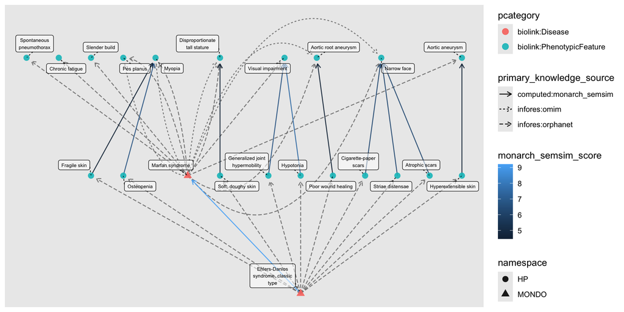

```r
library(ggraph)
plot(both_phenos, edge_color = monarch_semsim_score)
```

# Other Features

Other useful features are covered in dedicated Vignettes:

- Rollups and Transitivity - For computing transitive closures, transitive reductions, and rolling information up or down in directed acyclic graphs.
- Visualizing Knowledge Graphs - Basic plotting, compatible libraries, and plotting with `Cytoscape`.
- Exploring Knowledge Graphs - `summary()` for KG engines and sample graphs covering node categories.
- Engine Preferences - Determining the selection of node `pcategory` from available `category` values and other configurable engine properties.
[^1]: The `%in_list%` and other operators work the same for `file_engine()`s, which store multi-valued properties in list columns. Multi-value properties are typically represented as list columns in R, but `%in%` does not provide the desired semantics–try using both `%in%` and `%in_list%` to filter a `data.frame` on values of a list column to see the difference. Note that `%in_list%` can only take a length-one character vector as the left-hand side, and the right hand side must be a single node property name in the KG.
[^2]: The `limit` parameter for `expand()` is more complex than for `fetch_nodes()`, because the query graph also contains edges which may be part of the neighborhood that would be fetched; `expand()` attempts to fetch `limit` new edges that are not part of the query already. Further, unlike in `fetch_nodes()` where nodes are ordered by ID, edges returned by `expand()` have no explicit order, and results with `limit` should not be considered reproducible or representative.